# Bibliography - Curls & Contemplation

Copyright © 2025 by Michael David.

All rights reserved. No part of this book may be reproduced in any form without written permission from the publisher, except for brief quotations used in reviews or promotions.

ISBN: 978-0-9876543-2-1

Publisher Information:

Michael David Publishing

Los Angeles, California

2025

# DEDICATION

For those who see beauty where others see only hair—  
those who transform strands into stories, and texture into testimony.

To the *artists* whose hands tremble with excitement before they create, who see possibilities in every curl pattern and potential in every client. This is for you who have turned rejection into redirection, who understand that your uniqueness isn't a barrier but your greatest gift. Your fingertips hold magic that cannot be taught, only cultivated.

To the *apprentices* standing nervously with combs in hand, questioning your place: I was once you. Your doubt is the shadow of your greatness waiting to emerge. Study every movement of those before you. The way they listen with their hands, the silent language between stylist and client. These moments contain universes of wisdom.

And to my *lighthouse keepers* in the storm—**Yusef Williams**, who taught me that technique without heart is just mechanical motion; **Naeemah Lafond**, whose fierce advocacy showed me our work transcends beauty to become cultural affirmation; and **Vernon François**, who helped me see that every curl has a voice if only we'd listen carefully enough—thank you doesn't begin to cover the debt. You didn't just shape my hands; you sculpted my vision.

To *every hairstylist* reading these words: our craft is ancient magic in a modern world. We don't just style hair—we hold stories between our fingers, build confidence with our brushes, and weave heritage into every strand we touch.

The world is waiting for your signature touch.

# SELF-ASSESSMENT

This self-assessment is designed to help you reflect on your current journey as a freelance hairstylist. Take your time to answer each question thoughtfully.

1

What initially drew you to the art of hairstyling? What sparked your passion for this creative calling?

2

As you embark on this journey of conscious hairstyling, what are your biggest hopes, dreams, and aspirations for your craft and career?

3

Reflect on your current hairstyling techniques, philosophies, and practices. In what areas do you feel you have room to grow and evolve?

4

How would you describe your current approach to connecting with and understanding your clients' needs, desires, and unique beauty? How could you deepen this empathy and attunement?

5

What does being a "conscious hairstylist" mean to you at this stage? What values and intentions do you want to bring more fully into your work?

6

In what ways do you hope to make a positive impact on your clients, community, and the beauty industry through your hairstyling?

7

As you reflect on the current beauty industry, what opportunities do you see for greater inclusivity, sustainability, and empowerment? How might you contribute to that vision?

8

What self-care practices do you currently use to nurture your own well-being and creative inspiration? Where could you expand your repertoire?

9

What mentors, collaborators, or educational resources do you currently draw upon for ongoing growth and development? Where might you broaden your support network?

10

As you look ahead, what are you most excited to learn, experience, and create through the sacred art of hairstyling? What's calling to your heart?

# AFFIRMATION ODYSSEY

## Building Your Creative Confidence

This is more than an activity; it's a step toward personal growth. As you dive into this eBook, you'll gradually build your own affirmation, reflecting and finding your inner voice along the way. By the end, you'll have crafted a 12-line testament to your creativity and self-awareness. Start with your first three lines now and watch your affirmation take shape.

Your Affirmation

1

2

3

Inspiration

•

I am capable and strong, with endless potential.

•

Today, I move closer to my dreams.

•

My mind is focused; my heart and spirit are ready.

•

Challenges are opportunities for growth.

•

I deserve success, happiness, and fulfillment.

•

I learn, evolve, and improve daily.

•

My actions spread positivity.

•

I am thankful for every experience.

•

I believe in my vision and trust my journey.

•

I radiate positivity and resilience.

•

Every step is toward my true potential.

•

Daily, I grow stronger in my purpose.

Repeat these affirmations daily to remind yourself of your strength and potential.

# PREFACE

## Introduction to Curls & Contemplation

The creative spirit stirs, restless and unbounded by four walls. The familiar rhythms of appointment books and studio lighting begin to feel like beautiful constraints rather than destinations. In this pivotal moment of yearning for something more, Curls & Contemplation was born—not merely as a book, but as a manifesto for those who sense that their artistry deserves a canvas larger than the chair, a stage greater than the salon floor.

What you hold in your hands is a roadmap for the ambitious hairstylist who gazes beyond the horizon. This is not simply another guide to perfect your technique; it is a companion for your exodus from the conventional, illuminating pathways to expression, entrepreneurship, and expansion that exist when you dare to redefine what it means to be a hair artist in today's boundless landscape.

Throughout these chapters, I share not only the strategies that liberated my career from the confines of a single location, but the profound inner transformations required to reimagine my identity as an artist without borders. You'll witness the unfiltered journey of reinvention: from salon dependent to location independent, from service provider to content creator, from employee to visionary entrepreneur whose influence transcends physical space.

In a profession where most are taught that success means a loyal clientele and a busy chair, we face unique challenges when seeking to build something more expansive. Here, we redefine success entirely. The fear of walking away from consistent bookings? The catalyst for creating multiple revenue streams. The uncertainty of building a personal brand? Your gateway to genuine artistic freedom. The vertigo of entrepreneurial risk? The foundation of an empire that travels wherever your creativity leads.

Curls & Contemplation invites you to break through the invisible ceiling that keeps too many brilliant artists tethered to a single mode of expression. Within these pages, you'll discover how to translate your technical mastery into diverse opportunities—editorial work, education platforms, product development, digital content, and business models that generate income while you sleep.

As you turn each page, embrace the identity of pioneer rather than practitioner, of creator rather than service provider, of visionary rather than technician. The wisdom captured here isn't meant to simply improve your existing career, but to completely reimagine what's possible when you liberate your talents from traditional expectations and physical limitations.

Welcome to your professional metamorphosis. Welcome to a life and career designed entirely on your terms. Welcome to Curls & Contemplation.

With boundless creativity and unwavering belief in your journey beyond the chair,

Michael David

# Part I: Foundations of Creative Hairstyling

## Chapters I—III

Every masterpiece begins with a single stroke. As you turn these pages, you're not just learning techniques—you're unlocking the artistic legacy that flows through generations of visionary stylists. Here, in the crucible where science meets artistry, you'll discover why certain cuts create movement, how color theory transforms ordinary into extraordinary, and when to trust the intuition that separates good stylists from legends.

These foundational chapters aren't merely about holding scissors— they're about wielding the power to transform not just hair, but confidence, identity, and self-expression. Whether you're standing behind your first chair or seeking to reinvigorate decades of experience, these timeless principles will become the compass guiding your creative journey through every trend, every client, and every challenge that lies ahead.

I

Unveiling

Your

Creative

Odyssey

> "For we are God's handiwork, created in Christ Jesus to do good works, which God prepared in advance for us to do."

— Ephesians 2:10

## Introduction

**P**icture celebrity stylist Ursula Stephen, who transformed Rihanna's look early in her career, catapulting both the singer's and her own careers to new heights.<sup>1</sup> With each cut, Ursula shaped not only her client's confidence but also a bold public identity, proving that hairstyling is more than aesthetics—it's a powerful tool for self-expression and cultural influence.

In a society where hair can symbolize power, rebellion, and individuality, stylists like Stephen—and pioneers such as Madam C.J. Walker<sup>2</sup>—showcase how hairstyling holds the power to not only transform appearances but also to reshape societal expectations. This chapter embarks on a journey to explore the profound impact of conscious hairstyling. We'll delve into its ability to redefine lives, one cut, color, and conversation at a time. Prepare to challenge conventional beauty standards as we examine the multifaceted roles of hairstylists as artists, confidants, and agents of change. From understanding the psychological effects of hairstyling on self-esteem to tracing its cultural significance throughout history, we'll establish the groundwork for a paradigm shift in how we perceive and practice our craft.

But this exploration isn't purely theoretical—it serves as a call to action, an invitation to infuse your artistry with purpose, passion, and profound awareness. Through compelling stories, expert insights, and practical strategies, you'll acquire the tools to enhance your skills, forge meaningful connections with clients, and leverage the transformative power of conscious hairstyling. So, dear hairstylist, as you embark on this creative odyssey, remember: your hands wield the brush strokes of self-expression, your heart imbues colors of compassion, and your mind holds the power to shape perceptions. Let every snip, every style, and every interaction be intentional.

In the realm of conscious hairstyling, transformation begins the moment your client takes a seat in your chair. Are you ready to unlock the true potential of your craft and become a force for positive change in the world? Let's begin.

## Personal Anecdote: A Personal Discovery

I remember the morning I drove to a client's home—a small apartment she hadn't left in weeks. As a freelance stylist, I'd taken this house call thinking it would be a simple blowout for someone too busy to visit the salon. When she opened the door, I immediately saw how wrong I was. Her depression had anchored her to the couch, and her hair—unwashed and neglected for so long—had become painfully tangled. "I'm sorry," she whispered, embarrassed. "My daughter's wedding is tomorrow, and I just—I can't show up like this."

As I gently worked through her hair at her kitchen table, using warm water and infinite patience, we talked. With each knot I loosened, she seemed to release something heavier. By the time I finished styling her silver waves, the woman in the mirror barely resembled the one who had answered the door. She touched her reflection, eyes shining. "I forgot she was still in there," she said softly. Driving home afterward, I cried—finally understanding that my hands weren't just creating hairstyles; they were helping rebuild bridges between people and their forgotten selves. This wasn't just a job. It was sacred work.<sup>3</sup>

## Case Study: Ted Gibson's Transformative Approach

**Challenge:** Clients experiencing hair loss due to alopecia or chemotherapy often struggle with self-confidence and identity issues related to their appearance.

**Solution:** Celebrity stylist Ted Gibson employs compassionate listening and highly personalized approaches. He provides clients with tailored styling solutions that address their specific needs and challenges during difficult times.

**Outcome:** Through Gibson's empathetic work, clients feel empowered and beautiful during challenging periods. His dedication demonstrates the power of hairstyling to restore not only appearance but also self-confidence and a sense of identity.<sup>5</sup>

By focusing on each client's unique needs and fostering an inclusive, safe environment, stylists can uplift clients in ways that impact every aspect of their lives. When they leave your salon feeling seen, heard, and beautiful, this confidence radiates outward, creating a ripple effect of positivity.

## Actionable Steps

1. *Prioritize Active Listening:* During consultations, use open-ended questions like "What would make you feel most confident in your new look?"
2. *Educate Yourself on Appearance Psychology:* Explore books, workshops, or online courses on the psychological aspects of self-esteem.
3. *Foster a Diverse Environment:* Create an inclusive salon atmosphere celebrating all hair textures and cultural backgrounds.

### Exploring the Cultural and Social Significance of Hair Throughout History

Hair is far more than a personal style choice; it stands as a powerful symbol of cultural identity, social status, and historical legacy. Across various eras and societies, hair has acted as a marker of spirituality, defiance, and belonging. Recognizing and honoring these meanings allows hairstylists to deepen their appreciation for the cultural mosaic they contribute to with every style they create.

In ancient Egypt, for instance, elaborate wigs worn by pharaohs symbolized power and divine connection.<sup>7</sup> In the African American community, the Afro gained prominence during the 1960s civil rights movement—an emblem of pride and resistance against Eurocentric beauty standards.<sup>6</sup> Embracing these histories fosters an environment that celebrates diversity and honors the individuality of each client.

## Actionable Steps

1. *Create a Cultural Hairstyling Guide:* Research and compile references for various cultures and their hairstyles.
2. *Use Inclusive Language and Imagery:* Update marketing materials to reflect diverse hair types and aesthetics.
3. *Engage in Community Events:* Participate in or host workshops that celebrate cultural heritage within the beauty industry.

### Profiles of Influential Hairstylists and Their Unique Perspectives

To understand the transformative power of conscious hairstyling, we must look to the pioneers who have redefined our industry. Iconic figures like Vidal Sassoon revolutionized hairdressing in the 1960s with his geometric cuts, focusing on liberation and ease for women.<sup>8</sup> Today, stylists like Vernon François champion the natural beauty of curly and coily textures, challenging narrow beauty standards.<sup>10</sup> Larry Sims, Kim Kimble,<sup>9</sup> and others similarly shape industry norms by embracing inclusivity.

Drawing inspiration from these innovators allows you to evolve your own practice. Share their stories with clients and colleagues; celebrating these visionaries fosters a collective narrative of empowerment and inclusivity.

## Actionable Steps

1. *Wall of Inspiration:* Dedicate a salon space featuring quotes and images of influential stylists.
2. *Reflect on Philosophies:* Note which aspects of their vision align with your own approach.
3. *Share Stories with Clients:* Spark conversations that highlight the deeper meaning of your craft.

## II. The Hairstylist as Artist and Storyteller

### Embracing the Artistry and Creativity of Hairstyling

At the core of conscious hairstyling is the idea that it's an art form—a powerful medium for expressing creativity and individual vision. Approaching each client as a unique canvas elevates the craft, blending imagination with skillful technique. Inspirations can come from anywhere: nature, architecture, even vibrant cityscapes. Legendary editorial stylist Guido Palau, for instance, merges fashion with avant-garde concepts, proving that hair can become wearable sculpture.

## Actionable Steps

1. *Create a Mood Board:* Gather visuals—nature, fashion, architecture—to spark fresh ideas.
2. *Experiment with New Techniques:* Use mannequin heads for no-pressure practice.
3. *Collaborate on Styled Shoots:* Partner with local photographers or designers to push creative boundaries.

### Harnessing the Power of Storytelling in Hairstyling

In the hands of a conscious hairstylist, hair becomes a profound medium for storytelling—each cut, color, and style reflecting the client's personal journey. Renowned stylist Felicia Leatherwood is known for her emphasis on embracing natural textures and the cultural roots behind them, turning hairstyling into a tool for empowerment.

## Actionable Steps

1. *Develop Open-Ended Questions:* Ask, "What aspects of yourself would you like this style to express?"
2. *Practice Active Listening:* Watch verbal and non-verbal cues to uncover deeper emotions.
3. *Client Story Journal:* Keep a record of transformative client journeys for inspiration.

### The Intersection of Hairstyling and Identity Expression

Hairstyling is a powerful avenue for clients to affirm identity—whether cultural, personal, or gender-related. Stylists like Vernon François showcase how honoring the heritage behind textured hair fosters pride and challenges mainstream norms. Supporting clients through life transitions, or simply celebrating who they are, becomes an intimate, empowering process that requires trust, empathy, and respect.

*Actionable Steps:*

- *Invest in Educational Programs:* Seek training on gender identity, cultural significance, and specialized hair practices.
- *Display Inclusive Imagery:* Show visuals of diverse hair textures, ethnicities, and styles in your salon.
- *Adopt Gender-Neutral Pricing:* Base fees on complexity rather than outdated gender categories.

## III. Mastering Classic and Cutting-Edge Techniques

### Mastering Classic and Contemporary Methods

Excelling as a conscious hairstylist requires a solid foundation in timeless techniques, combined with a willingness to explore new methods. Vidal Sassoon's geometric cuts revolutionized hairstyling in the 1960s, while color experts like Tracey Cunningham demonstrate the importance of staying updated on modern trends.

*Actionable Steps:*

- *Personal Education Plan:* Outline regular skill-refresh intervals—monthly, quarterly, or yearly.
- *Attend Industry Events:* Stay current on new products and approaches.
- *Practice on Mannequins:* Hone advanced techniques before offering them to clients.

### Exploring Texture and Embracing Natural Styles

With movements celebrating natural hair, stylists have opportunities to specialize in textured hair. Experts like Felicia Leatherwood and Nai'vasha Johnson emphasize techniques (e.g., finger-coiling, the Curly Girl method) that help clients embrace their curls.

*Actionable Steps:*

- *Invest in Texture Education:* Seek workshops on Afro-textured hair care and styling.
- *Create a Texture Bar:* Showcase products specifically for curls, coils, and kinks.
- *Diverse Portfolio:* Feature wide-ranging examples of styles in your lookbook and salon décor.

### Harnessing Technology and Social Media for Inspiration

Platforms like Instagram and TikTok let stylists share transformations, discover global trends, and engage with peers. Celebrity stylist Jen Atkin exemplifies how leveraging social media can build a personal brand and attract loyal clients.

*Actionable Steps:*

- *Content Calendar:* Plan posts or videos showcasing new styles and tips.
- *Online Challenges:* Participate to spark creativity and expand your skill set.
- *AR Tools:* Let clients "try on" looks digitally for greater confidence.

## IV. Understanding Diverse Hair Types and Championing Representation

### Unique Needs and Textures

From Solange's iconic looks to Tracee Ellis Ross's celebration of curls, stylists such as Chuck Amos demonstrate deep knowledge of the variations in density, porosity, and scalp health among different hair types.

*Actionable Steps:*

- *Hair Type Guide:* Develop a resource clarifying differences in porosity, pattern, and more.
- *Ongoing Training:* Stay updated on best practices for a wide range of textures.
- *Stock a Diverse Product Inventory:* Ensure all clients can find suitable haircare solutions.

### Championing Representation and Diversity in Salon Practices

Salon culture thrives when it celebrates a variety of identities. Stylists like Ted Gibson advocate for representation in staff, clientele imagery, and product lines—practices that build trust among diverse communities.

*Actionable Steps:*

- *Diversity Audit:* Review marketing, décor, and hiring policies for inclusivity.
- *Inclusive Training:* Ensure staff are culturally competent.
- *Community Partnerships:* Collaborate with local organizations to host inclusive beauty events.

### Cultivating Cultural Competence and Sensitivity

Understanding the religious or cultural significance of certain hairstyles fosters deeper respect. Ursula Stephen's approach to Rihanna's look, for example, involves capturing not just a bold style but also elements of personal identity. By honoring traditions, you create more affirming client experiences.

*Actionable Steps:*

- *Enroll in Cultural Competence Courses:* Seek out specialized training to learn about diverse cultural hair practices.
- *Build a Resource Library:* Keep a collection of articles and references on cultural hairstyles.
- *Encourage Client Feedback:* Continuously refine inclusivity by listening to client experiences.

## V. The Consultation: Co-Creating the Vision

A successful consultation is about more than technical details; it's an opportunity for clients to feel seen, valued, and understood. From Sally Hershberger's signature approach to Meg Ryan's shag cut, to Sam McKnight's transformations for Princess Diana, industry leaders emphasize empathy and attentiveness when helping clients articulate their style identity.

### Active Listening and Observation

Stay present for verbal and non-verbal cues. Some clients might verbally request a bold change yet hesitate in their body language. By noticing these signals, you can address concerns and collaboratively refine the vision.

*Actionable Steps:*

- *Consultation Checklist:* Include questions about lifestyle, maintenance preferences, and style goals.
- *Mindfulness Techniques:* Practice deep breathing before consultations to maintain focus.
- *Private Consultation Space:* Provide a calm area to encourage openness.

### Guiding Clients in Defining Their Unique Hair Identity

Help clients envision how their hair can reflect their personal and professional aspirations. Use visual aids such as lookbooks and style quizzes to inspire clarity. Sam McKnight famously guided Princess Diana's shift from a classic bob to a more modern look that showcased her evolving public image.

*Actionable Steps:*

- *Style Personality Quiz:* Gather info on lifestyle, color preferences, and hair goals before appointments.
- *Diverse Lookbook:* Curate images categorized by face shape, hair texture, and lifestyle needs.
- *Digital Imaging System:* Offer virtual try-ons to reduce uncertainty.

### Co-Developing a Holistic Hair Care Plan

Once the desired style is defined, craft a plan that includes both in-salon services and at-home maintenance. Kristin Ess is known for equipping clients with thorough product knowledge, boosting their confidence to maintain fresh styles.

*Actionable Steps:*

- *Care Plan Templates:* Customize instructions for each client's texture, color, and daily routine.
- *Educational Video Series:* Provide tutorial clips for common styling challenges.
- *Follow-Up System:* Check in weeks later to assess satisfaction and make adjustments.

## VI. Building and Nurturing Client Relationships

### Creating a Welcoming and Inclusive Salon Environment

Every client should feel valued upon arrival. Devachan in NYC focuses on imagery that showcases all hair textures, setting a relaxed, accepting tone.

*Actionable Steps:*

- *Inclusivity Training:* Regular sessions for staff on cultural competence and empathy.
- *Client Feedback System:* Surveys or comment cards encourage ongoing improvement.
- *Inclusive Décor:* Display artwork reflecting diverse hair types and backgrounds.

### Fostering Trust and Loyalty with Empathy

Celebrity stylist Ted Gibson highlights listening and empathy to understand each client's unique story. A personal touch—remembering birthdays or style preferences—reinforces trust and loyalty.

*Actionable Steps:*

- *CRM System:* Track preferences, service history, and notes for personalized visits.
- *Comfort Menu:* Offer small add-ons (aromatherapy, scalp massage) for a premium experience.
- *Staff Sensitivity Training:* Equip team members to handle emotional moments with compassion.

### Educating and Empowering Clients

Offering knowledge on at-home care fosters stronger relationships. Kim Kimble, known for her work with Beyonce, invests in client education to ensure their look stays vibrant beyond the salon.

*Actionable Steps:*

- *Client Education Workshops:* Teach styling tips, product usage, and healthy routines.
- *Online Resource Library:* Post blog entries or tutorial videos for easy reference.
- *Style Challenge:* Encourage clients to track hair progress at home, building a supportive community.

## VII. Thriving as a Freelance Hairstylist

### Cultivating a Mindset of Abundance and Resilience

Freelancing demands autonomy, adaptability, and resilience. Stylist Kristin Ess exemplifies a mindset of abundance, focusing on community collaboration rather than competition.

*Actionable Steps:*

- *Gratitude and Success Journal:* Capture positive milestones to maintain an uplifting outlook.
- *Build a Support Network:* Engage with fellow freelancers, share resources, and advice.
- *Set Milestone Goals:* Break big ambitions into smaller steps to stay motivated.

### Effective Business and Marketing Strategies

Treat hairstyling as both an art and a business. Define your brand and marketing to resonate with your ideal clientele. The haircare brand Amika, for example, used social media to create a relatable identity that drew a wide audience.

*Actionable Steps:*

- *Detailed Business Plan:* Outline branding, pricing, and marketing channels.
- *Leverage Social Media:* Use Instagram, TikTok, or Pinterest to show your work and processes.
- *Referral Program:* Reward clients who bring friends, creating organic growth.

### Balancing Artistry, Entrepreneurship, and Self-Care

Balancing a passion for hair with business tasks can be challenging. Jen Atkin schedules downtime to protect her creative energy and overall wellness.

*Actionable Steps:*

- *"Creative Days":* Devote time for experimentation or personal projects.
- *Set Boundaries:* Limit after-hours business communications to safeguard mental health.
- *Professional Wellness Groups:* Join communities focused on self-care for stylists.

## VIII. Ethical and Sustainable Practices in Hairstyling

### Choosing Eco-Friendly Products

Selecting non-toxic, sustainable products benefits clients and the planet. Tabitha James-Kraan, a pioneer in organic haircare, emphasizes safe, high-quality formulas.

*Actionable Steps:*

- *Eco-Friendly Product Line:* Offer sulfate- and paraben-free options.
- *Salon Recycling Program:* Provide incentives for returning or recycling empty containers.
- *Educate Clients:* Display in-salon materials highlighting the benefits of eco-conscious choices.

### Collaborating with Values-Aligned Professionals

By partnering with eco-conscious companies and advocacy groups, you expand your impact beyond the chair. John Masters, for instance, built a brand on organic principles through collaboration with like-minded organizations.

*Actionable Steps:*

- *Join Sustainability Networks:* Connect with industry peers committed to green practices.
- *Eco-Friendly Event Partnerships:* Support or host environmental awareness gatherings.
- *Community Clean-Ups:* Engage salon staff and clients in local cleanup initiatives.

### Advocating for Industry Reform and Consumer Education

Stylists can drive ethical shifts by educating clients and setting sustainable standards. Jack Martin, famous for dramatic color corrections, uses his platform to encourage mindful product choices.

*Actionable Steps:*

- *Educational Content:* Blog or vlog about eco-friendly haircare practices.
- *Industry Panels:* Contribute your voice in workshops or discussions on ethical hairstyling.
- *Conscious Consumer Guide:* Offer a brief resource outlining how clients can choose sustainable options.

## IX. Crafting Your Unique Hairstyling Legacy

### Defining Your Personal Mission and Values

Building a lasting legacy starts with clarity. Vidal Sassoon's mission to create liberating styles shaped generations. Defining your purpose ensures your daily work aligns with meaningful impact.

*Actionable Steps:*

- *Personal Mission Statement:* Write down your overarching goals and values.
- *Vision Board:* Collect quotes and images that mirror your stylistic aspirations.
- *Regular Self-Check:* Periodically ask if your work still reflects your mission.

### Investing in Lifelong Learning and Growth

Orlando Pita stays ahead by constantly updating his skill set. Lifelong learning ensures relevance and keeps your passion alive.

*Actionable Steps:*

- *Annual Learning Goals:* Pick specific skills or knowledge areas to explore each year.
- *Workshops & Conferences:* Network and learn from peers.
- *Professional Development Budget:* Set aside funds exclusively for education.

### Leaving a Legacy of Positive Impact and Change

Holli Smith's commitment to inclusive styling sets a new bar for the industry. By embedding your values in daily practice, you create ripples far beyond your individual clients.

*Actionable Steps:*

- *Mentorship Program:* Guide new stylists with an emphasis on inclusive and sustainable methods.
- *Track Impact:* Note changes in client confidence and industry progress you help spark.
- *Scholarships or Grants:* Support aspiring stylists from underrepresented backgrounds.

## Making Time for Growth

It's easy to feel too busy for self-reflection, but even short, daily moments of mindfulness reinforce your creative purpose. Below is a quick-start guide for stylists juggling hectic schedules:

**Quick Start Guide (15 Minutes or Less)**

- **Morning Mantra (1–2 minutes):** Whisper an affirmation like "I uplift others through my creativity."
- **Gratitude Glimpse (3 minutes):** Jot down something you're thankful for—whether personal or professional.
- **Mini Reflection (5 minutes):** At day's end, ask, "What moment truly lit me up today?"
- **Quick Salon Spark (5 minutes):** Keep a notebook or phone app handy for flashes of color inspiration or interesting style ideas.

Incorporating these bite-sized practices into your daily life helps you remember that hairstyling isn't just a job—it's a meaningful journey for both you and your clients.

## Implementation Roadmap

Based on your current challenges or goals, here's how you can navigate subsequent chapters or sections within this book:

- **Need advanced technical insights?** See sections on *Mastering Classic and Cutting-Edge Techniques*.
- **Battling creative burnout?** Find renewal ideas under *The Hairstylist as Artist and Storyteller*.
- **Ready to refine your freelance approach?** Head to *Thriving as a Freelance Hairstylist* for business tips.
- **Prioritizing ethics and sustainability?** Explore *Ethical and Sustainable Practices* for eco-friendly strategies.

Pick whichever path resonates most with your immediate needs while keeping in mind that everything ties back to the overarching message of conscious, purpose-driven hairstyling.

## Chapter Conclusion

Conscious hairstyling extends beyond skillful cuts and beautiful color—it's about empowering clients to see themselves fully, fostering inclusivity, and nurturing your own growth along the way. By aligning empathy, technical mastery, and ethical awareness, you become a guiding force for transformation in the salon and beyond. Let each moment behind the chair be a chance to honor the unique stories that flow through every strand of hair.

Remember: you shape more than appearances. You shape confidence, identity, and a more inclusive industry. This creative odyssey is yours to explore—one thoughtful snip at a time.

## Endnotes

1. Allure, "The Secret Behind Rihanna's Iconic Hairstyles: Meet Ursula Stephen," Allure, April 18, 2017, https://www.allure.com/story/ursula-stephen-hairstylist-rihanna.
2. A'Lelia Bundles, *On Her Own Ground: The Life and Times of Madam C.J. Walker* (New York: Alfred A. Knopf, 2001).
3. Jennifer Atkin, *Blowing My Way to the Top: How to Break the Rules, Find Your Purpose, and Create the Life and Career You Deserve* (New York: Harper Wave, 2020).
4. Thomas F. Cash and T. A. Pruzinsky, "The Role of Physical Appearance in Shaping Self-Perception: Implications for Mental Health," *Psychology and Health* (2002).
5. D. Thomas, "Ted Gibson's Journey of Empowering Clients Through Hairstyling," *Essence*, June 20, 2019, https://www.essence.com.
6. Kobena Mercer, *Welcome to the Jungle: New Positions in Black Cultural Studies* (London: Routledge, 1994).
7. The Metropolitan Museum of Art, "Hair and Wigs in Ancient Egypt," accessed March 8, 2025, https://www.metmuseum.org/toah/hd/hair/hd_hair.htm.
8. Vidal Sassoon and Michael O'Donnell, *Vidal: The Autobiography* (New York: Macmillan, 2010).
9. Byrdie, "An Interview with Celebrity Hairstylist Kim Kimble," Byrdie, 2017, https://www.byrdie.com/kim-kimble-interview.
10. G. Escandon, "How Vernon François Went From Braiding Mops to Brand Founder," *Modern Salon*, May 25, 2021, https://www.modernsalon.com/article/121820/how-vernon-francois-went-from-braiding-mops-to-brand-founder.

## Quiz

### Question 1

What is one key characteristic of "conscious hairstyling" as described in this chapter?

- A) Focusing only on technical precision and speed
- B) Recognizing the deep psychological influence hair has on self-esteem and well-being
- C) Using only the most expensive products and tools

### Question 2

Which example highlights the importance of a stylist's empathy when working with clients?

- A) Ted Gibson's compassionate approach with clients experiencing hair loss
- B) Vidal Sassoon's geometric cutting techniques
- C) Celebrity stylists working on red carpet events

### Question 3

Why are inclusive marketing materials significant in a salon setting?

- A) They cost less to produce than traditional materials
- B) They help celebrate diversity and honor individuality of each client
- C) They are required by law in most states

### Question 4

What benefit can arise from implementing a brief "Quick Start Guide" for growth?

- A) It guarantees immediate financial success
- B) It provides structured, actionable steps for professional development
- C) It replaces the need for formal training or education

## Worksheet

### Reflection and Implementation Exercises

1. **Reflect on the personal anecdote about helping someone rediscover themselves through hairstyling. Have you had a similar moment in your career? Write a few sentences describing it.**

_____________________________________________________________________

_____________________________________________________________________

_____________________________________________________________________

1. **Look at the "Quick Start Guide" ideas—list one or two that fit your schedule. How will you incorporate them into your daily routine?**

_____________________________________________________________________

_____________________________________________________________________

_____________________________________________________________________

1. **Where do you see yourself needing immediate growth: advanced techniques, cultural competence, business skills, or something else? Outline one action you'll take this week.**

_____________________________________________________________________

_____________________________________________________________________

_____________________________________________________________________

1. **If you were to define your personal hairstyling mission in a sentence, what would it be?**

_____________________________________________________________________

_____________________________________________________________________

_____________________________________________________________________

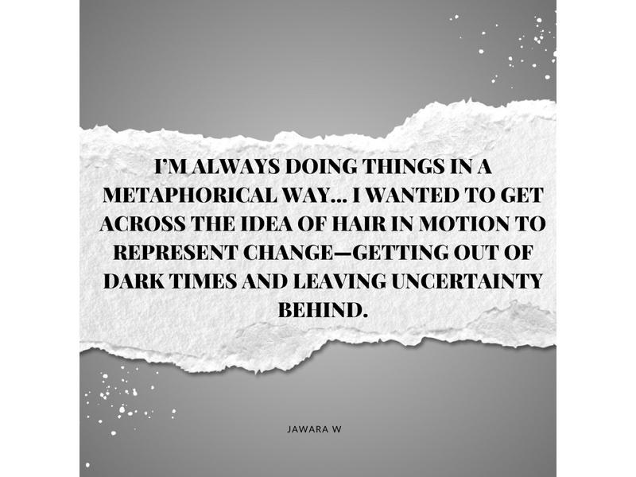

I’m always doing things in a metaphorical way… I wanted to get across the idea of hair in motion to represent change—getting out of dark times and leaving uncertainty behind. — Jawara W

II

Refining

Your

Creative

Toolkit

> "Do you see someone skilled in their work? They will serve before kings; they will not serve before officials of low rank."

— Proverbs 22:29

## Introduction

**H**ave you ever watched a master artist at work and marveled at how their tools seem to become extensions of their very being? Picture a sculptor’s hands caressing a block of marble, their chisel poised to unveil the masterpiece within. Envision a painter’s brush dancing across the canvas, each stroke breathing life into a world of color and emotion. Now, imagine yourself standing before your client, shears in hand, ready to transform not just hair but confidence, identity, and self-expression.

In the realm of hairstyling, your tools are far more than mere instruments—they are the conduits through which your creativity flows, extensions of your artistic vision, and keys to unlocking your client’s true beauty. Just as a violinist’s bow becomes an extension of their arm, your shears, combs, and brushes become extensions of your hands, allowing you to sculpt, shape, and breathe life into each unique head of hair before you.[^1]

This chapter invites you on a transformative journey to refine your creative toolkit—to explore the profound relationship between artist and instrument and unlock the full potential of your craft. We’ll delve into the art of selecting the perfect tools for diverse techniques and textures, uncover the science of maintaining your instruments for optimal performance, and reveal the alchemy of mastering tool techniques to elevate your artistry to new heights.

## The Right Tools Empower Artistry and Precision

Imagine holding a pair of shears that feel like an extension of your own hand—so perfectly balanced and precise that every snip becomes an act of artistry. Can you feel the power and potential coursing through your fingertips? This is the transformative magic that the right tools can bring to your craft.

In the world of hairstyling, innovation in tools plays a critical role in achieving both precision and hair health. Brands like Dyson and T3 are at the forefront of this technological revolution, designing tools that not only enhance your ability to style but also minimize heat damage and prioritize your client’s hair health. Dyson’s advanced blow dryers, with their intelligent heat control, help reduce exposure to extreme temperatures, allowing you to create smooth, polished styles without compromising hair integrity. Similarly, T3’s flat irons and curling tools utilize digital technology to deliver consistent, even heat, ensuring that each styling session is as gentle as it is effective.[^2]

The legendary Guido Palau, in his seminal work *Hair: Guido* (2013), emphasizes a truth that resonates deeply within our profession: the right set of tools has the power to unleash the full spectrum of a stylist’s creative vision and technical precision.[^3] This synergy between artist and instrument transforms a simple haircut into a canvas for artistic expression and intricate braided styles into living, breathing works of art.

## Selecting the Right Tools for Diverse Techniques and Textures

Picture yourself standing before a vast array of hairstyling tools, each one holding the potential to transform your client’s hair—and their confidence. How do you choose? In the vibrant tapestry of hairstyling, where each client presents a unique canvas of texture and possibility, the ability to select the perfect tool for every situation is an art form in itself.

### Understanding Hair Types and Choosing the Perfect Tools

The foundation of effective tool selection lies in a deep understanding of hair types and textures. As emphasized by industry pioneers P. Cutting, R. Ross, and R. Hill in *Hairdressing: Theory, Science and Practice* (1988), success hinges on tailoring your tool selection to the specific characteristics of each client’s hair.[^4]

**Fine, Straight Hair** For this delicate hair type, precision is paramount. Imagine running your fingers through gossamer-fine strands—how would you approach styling without causing damage? Sharp, lightweight shears are essential for creating clean, crisp lines without causing split ends. Lightweight, ceramic-coated flat irons for sleek looks and round brushes that add volume become your best allies.

**Thick, Wavy/Curly Hair** Working with thick, textured hair requires tools that manage volume while enhancing natural patterns. Wide-toothed combs, detangling brushes, diffuser attachments, and deep conditioning products are crucial for maintaining moisture while reducing frizz.

**Coarse, Coily Hair** For highly textured hair, tools that prioritize moisture retention and gentle manipulation are essential. Specialized detangling brushes like Denman or Felicia Leatherwood styles, hooded dryers, and wide-barrel curling irons or rods help stylists shape and define while safeguarding delicate coils.

## Case Study: Celebrity Stylist Chris Appleton

**Challenge:** Working with diverse high-profile clients like Jennifer Lopez and Kim Kardashian, each with unique hair characteristics and demanding standards.

**Solution:** Appleton carefully selects tools specific to each client’s needs—high-quality flat irons with adjustable heat settings for precision styling, diffusers for enhancing curly textures, and specialized volumizing products for fine hair types.

**Outcome:** This meticulous tool selection approach ensures optimal hair health, exceptional shine, and style longevity, contributing to his success as a sought-after celebrity stylist.[^5]

## Personal Anecdote: The Scissors That Changed Everything

I’ll never forget the day my entire perspective on professional tools shifted. It was during New York Fashion Week, my third season assisting the lead stylist for a major designer. I had been saving for months to upgrade my kit but was still using the same mid-range shears I’d purchased fresh out of cosmetology school.

The call time was 4 AM, the pressure intense, and the look required precise, textured ends on twenty-three models within a three-hour window. Halfway through the preparations, disaster struck—my scissors slipped while cutting a crucial section on the designer’s favorite model, creating an uneven chunk where there should have been a seamless transition. I froze, feeling the weight of dozens of eyes on me as the lead stylist assessed the damage.

Without a word, she handed me her own scissors—custom Japanese shears that cost more than my monthly rent. “Finish it,” she said quietly. The moment I began cutting with them, I understood. The precision, the balance, the way they moved through the hair like they were extensions of my fingers rather than tools in my hands—it was revelatory. I not only salvaged the cut but elevated it, creating movement that caught the light as the model walked.

After the show, the designer specifically complimented that model’s hair, asking what we’d done differently. On the subway ride home, clutching my paycheck, I made a decision that would alter my career trajectory. Instead of paying down my student loans that month, I invested in my first pair of professional-grade shears.

Three weeks later, a client who had always been satisfied but never thrilled with my work gasped when she saw her reflection. “What did you do differently?” she asked, turning her head to admire the seamless layers. I hadn’t changed my technique—only my tools. That client became my biggest referral source, and within six months, my clientele had doubled.

I learned that day that in the hands of a stylist, tools aren’t just implements—they’re collaborators in creation. The right ones don’t just make your job easier; they expand what’s possible. Now, ten years into my career, I can trace every significant professional leap back to moments when I refused to compromise on what I put in my hands.

## Building Your Kit at Every Budget

One of the biggest concerns stylists face when refining their toolkit is cost. You may be fresh out of school, running a lean freelance operation, or simply unsure of where to invest first. Below is a tiered breakdown to help you navigate these choices:[^6]

- **Starter/Student:** *Budget Range:* $50–$100 for core items (shears, combs, brushes) *Focus:* Basic quality, reliability, and safety. *Key Tip:* Stick to reputable mid-tier brands; avoid unbranded, ultra-cheap kits that fall apart quickly.
- **Mid-Range Professional:** *Budget Range:* $100–$300 per major tool (shears, blow dryer, flat iron) *Focus:* Improved ergonomics, durable materials, moderate heat technology. *Key Tip:* Look for brand warranties and consider each tool an investment you’ll maintain for 2–3 years.
- **Pro/High-End:** *Budget Range:* $300+ per major tool *Focus:* Top-of-the-line materials, cutting-edge tech, long-term reliability. *Key Tip:* Often includes advanced heat controls, better balance, and premium blade steels. Typically last many years when well-maintained.

## Cost-Per-Use Analysis

- *Premium Shears (3 years):* Approx. $400 / (3 years × 12 months) ≈ $11.11 per month
- *Budget Shears (6 months):* Approx. $50 / (6 months) ≈ $8.33 per month But factor in time lost to re-sharpening, potential client dissatisfaction if the blades dull quickly, and replacement costs.

When you calculate **cost per use**—and the difference in performance—investing in better tools can be a wise move. Your clients notice the results, and word-of-mouth referrals often increase when your cuts and styles become more precise and consistent.

## Essential vs. Optional Tools

With so many tools on the market, it’s easy to feel overloaded. Here’s a quick reference to help prioritize:

- **Essential:** *Quality Shears:* The backbone of every cut. *Professional Blow Dryer:* Minimizes heat damage; an ionic or ceramic model can transform your finishing work. *Brushes & Combs:* A variety of sizes/materials for different hair textures (round, paddle, detangling, tail combs). *Basic Hot Tools:* One flat iron and one curling iron/wand to handle everyday styling.
- **Optional (But Helpful):** *Specialty Shears:* Thinning, texturizing, or chunking shears for advanced cutting techniques. *Multiple Curling Irons:* Various barrel sizes to create different curl patterns. *Advanced Heat-Styling Tools:* Waving irons, crimpers, or triple-barrel wavers. *Steam Pods or Infrared Dryers:* Tech-savvy stylists may leverage these for gentler treatments.

By focusing on the essentials first, you create a strong foundation. From there, add specialized tools that align with your chosen niches—bridal updos, textured hair, avant-garde looks, and more.

## Maintaining Your Tools for Optimal Performance and Longevity

Imagine the disappointment of reaching for your favorite shears, only to find them dull and ineffective. Or picture the frustration of a styling tool failing mid-session, leaving both you and your client in a lurch. How would these scenarios impact your work, your client’s trust, and your professional reputation?

Just as a painter meticulously cleans their brushes or a chef hones their knives, the conscious hairstylist understands that proper maintenance of their tools is not just about preserving an investment—it’s about ensuring consistent, high-quality results and upholding the highest standards of professionalism and client care.

### Techniques for Cleaning and Disinfecting Tools

Liz Farr, in her *Hairdressing Design: A Salon Handbook* (2012), emphasizes the importance of regular cleaning and disinfection:[^8]

- **Daily Cleaning:** Wipe down tools with disinfectant, remove hair/product residue, and pay attention to crevices.
- **Weekly Disinfection:** Soak tools in professional-grade solution. Use specialized wipes for electrical tools. Inspect for wear or damage.

Beyond cleanliness, these steps demonstrate care for your clients’ safety and reinforce your salon’s professional environment.

### Sharpening and Servicing

- **Cutting Tools:** Professional sharpening every 6–12 months keeps blades precise and hair healthy. Oil pivot points regularly.
- **Electrical Tools:** Annual servicing ensures peak efficiency. Clean vents and filters to prevent overheating.

### Proper Storage Techniques

- Use a quality case or bag with compartments to prevent scratching and damage.
- Store shears in protective sleeves when not in use.
- Keep electrical tools unplugged and away from water sources.
- A dehumidifier in humid climates helps prevent rust and corrosion.

By caring for your tools, you not only protect your investment but also maintain a professional standard that clients trust and value.

## Mastering Tool Techniques for Precision and Creativity

Close your eyes for a moment and imagine a virtuoso violinist on stage, their bow dancing across the strings with effortless grace. Now, look at your own hands—can you see the same potential for artistry and precision? Just as a musician spends countless hours perfecting their technique, the conscious hairstylist must dedicate themselves to mastering the intricate dance between hand and tool.

### Foundational Skills and Techniques

- **Precise Cutting:** Blunt cutting, point cutting, slide cutting. Maintain consistent tension and finger positioning.
- **Blow-Drying Mastery:** Control heat and airflow using round, paddle, or vented brushes. Create volume or smoothness strategically.
- **Basic Styling:** Hone braiding, twisting, and updos. Adapt to different textures for versatile results.

### Elevating Techniques for Advanced Looks

- **Advanced Cutting:** Texturizing, channel cutting, razor work. Experiment for editorial-inspired styles.
- **Color Application:** Balayage, ombré, color melting. Use brushes, foils, or combs for precise application.
- **Intricate Styling:** Complex braiding, weaving, extensions, and wig customization. Requires a range of specialized tools.

Digital platforms like Instagram or TikTok can complement in-person training. Tagging along with #HairEducation or #HairstylistTips provides instant inspiration and fosters a virtual learning community.

## Case Studies: Iconic Hairstylists and Their Tool Mastery

Studying renowned hairstylists can offer insights into how mastering tools shapes industry impact.

### Vidal Sassoon: Precision Cutting Pioneer

Sassoon’s trademark geometric bobs and five-point cuts relied on impeccably sharp shears and meticulous technique. By prioritizing precision, he liberated women from high-maintenance styles, influencing global trends and shifting cultural beauty norms.[^9]

### Guido Palau: Editorial and Runway Innovator

Known for avant-garde styling, Palau uses advanced heat tools (like GHD Platinum+ stylers) and sometimes unconventional objects (metal rods, paper) to sculpt dramatic, textured runway looks. His willingness to push boundaries redefines what tools can do.[^10]

### Kim Kimble: Champion of Textured Hair

Specializing in natural and textured styles, Kimble tailors her toolkit to preserve curl integrity—choosing high-quality diffusers, detangling brushes, and product lines that nourish coils and kinks. Her approach proves that artful tool usage can celebrate cultural identity.[^11]

## Implementation Roadmap

Ready to integrate these insights? Here’s a concise roadmap for putting it all into practice:[^12]

1. **Assess Your Current Toolkit:** List each tool you own, its condition, and whether it meets your standard for quality. Identify missing essentials first.
2. **Set a Budget & Prioritize:** Refer to “Building Your Kit at Every Budget” to decide what’s feasible now vs. later. Look at “Essential vs. Optional Tools” to focus on must-haves.
3. **Create a Maintenance Calendar:** Include daily wipe-downs, weekly disinfection, and monthly or quarterly checkups. Schedule blade sharpening or dryer filter cleaning in advance.
4. **Practice One New Technique Weekly:** Dedicate time for refining either a cutting or styling method. Record your progress with photos or notes.
5. **Track Client Feedback:** Notice if clients compliment the changes (e.g., smoother cuts, healthier hair). Encourage them to share reviews or refer friends.

By following these steps, you gradually elevate both the performance of your toolkit and your personal artistry—without overwhelming your schedule or finances.

## Conclusion: The Lifelong Revolution of Skill Mastery

As we conclude our exploration of refining your creative toolkit, reflect on the journey we’ve undertaken. How has your perspective on your tools and techniques evolved? What new possibilities can you envision for your artistry?

It’s clear that the journey of a conscious hairstylist is one of perpetual growth, innovation, and self-discovery. The path to mastery isn’t a single destination but an ongoing cycle of learning, experimenting, and evolving—keeping your craft vibrant and your passion alive.

Each instrument in your kit holds the potential to translate your creative vision into reality. Yet it’s the synergy of **technical skill** plus **artistic intent** that breathes life into every style you create. By choosing tools that resonate with your approach, maintaining them diligently, and pushing the boundaries of your technique, you empower yourself to deliver transformative experiences for your clients.

Embrace each challenge as an opportunity to grow. Stay curious about new technologies, methods, and styles. Above all, remember: your ultimate goal isn’t just to craft beautiful hair; it’s to uplift and celebrate the person sitting in your chair.

Let this chapter be a reminder that the scissor, brush, or dryer in your hand isn’t just a piece of equipment—it’s a collaborator in your creative journey. Approach it with respect, passion, and a commitment to excellence, and watch how it reshapes both your artistry and your clients’ sense of self.

How will you integrate these new insights into your daily practice? Which budget-friendly tool might you upgrade first? And how will you maintain your commitment to continuous skill mastery? The revolution of your artistry is an ongoing story—let this be the chapter where you step boldly into the next level of your craft.

## Key Takeaways

- Tools are **extensions of your artistry**—invest wisely, balancing budget with long-term value.
- **Mastery** evolves through continuous learning, thoughtful experimentation, and staying open to new technologies.
- **Tool maintenance** is essential for consistent, high-quality results—and it safeguards your professional reputation.
- Study industry icons for inspiration, but develop your **unique style** by adapting techniques to your vision.
- Embrace an **implementation roadmap** to gradually refine your toolkit without overwhelming your finances or schedule.
- Ultimately, your goal is to **empower clients** by elevating their confidence through creative, precise hairstyling.

## Quiz

### Question 1

What does "mastery" mean in the context of hairstyling according to this chapter?

- A) Mastery means having the most expensive tools
- B) Mastery means never needing to learn new techniques
- C) Mastery is an ongoing cycle of learning, experimenting, and evolving
- D) Mastery means catering exclusively to high-end clients

### Question 2

Which of the following is most accurate regarding professional-grade tools?

- A) They're unnecessary luxuries for beginners
- B) They often prove cost-effective when calculating cost-per-use over time
- C) They require less maintenance than budget tools
- D) They're only needed for celebrity clients

### Question 3

What is the recommended frequency for professional sharpening of cutting tools?

- A) Weekly
- B) Every 6-12 months
- C) Only when visibly damaged
- D) Every 5 years

### Question 4

Which approach best describes Vidal Sassoon's impact through his tool mastery?

- A) Creating high-maintenance styles
- B) Using unconventional objects for styling
- C) Precision cutting that liberated women from high-maintenance styles
- D) Focusing exclusively on textured hair

## Worksheet

### Mastery and Tool Care

Take a few minutes to reflect on your relationship with your tools and your journey toward mastery. Use these prompts to deepen your understanding and set intentions for your ongoing growth as a conscious hairstylist.

1. **Defining Mastery:** What does “mastery” mean to you in your hairstyling career? List one or two areas (technical or creative) where you’d like to improve.
2. **Tool Maintenance Routine:** Outline a simple daily or weekly schedule for cleaning, disinfecting, and storing your tools. How can you stay consistent?
3. **Embracing Better Equipment:** Are there specific tools you’ve hesitated to purchase due to cost? What’s one step you can take to budget or save for that upgrade?
4. **Crafting an Affirmation:** Write three lines that affirm your growth mindset and dedication to refining your toolkit:

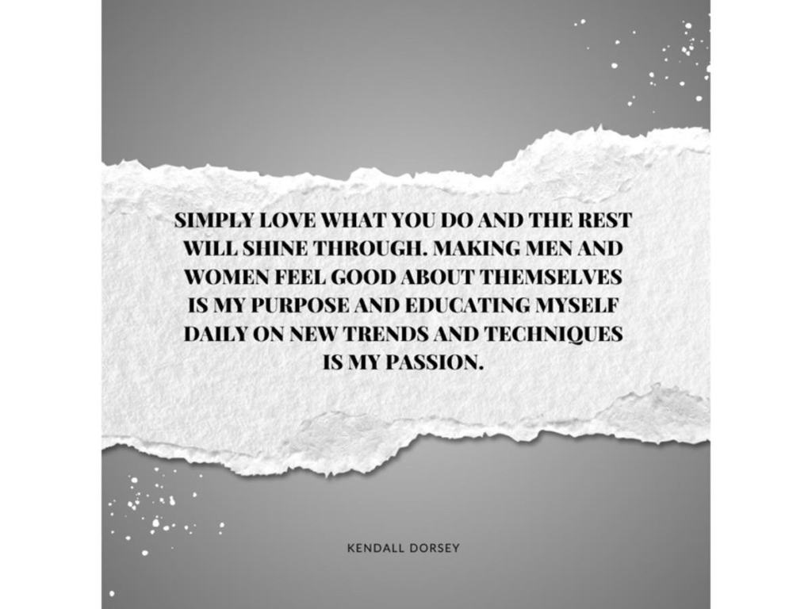

1. Daniel Goldstein, “The Extended Mind in Creative Practice: How Tools Become Extensions of Ourselves,” *Creativity Research Journal*, 2021, https://www.creativityresearchjournal.org/extended-mind. ↩︎
2. Dyson, “Dyson Supersonic Hair Dryer,” 2023, https://www.dyson.com/hair-care/dyson-supersonic; T3 Micro, “Innovative Hair Styling Tools,” 2023, https://www.t3micro.com/hair. ↩︎
3. Guido Palau, *Hair: Guido* (New York: Rizzoli International Publications, 2013). ↩︎
4. Paul Cutting, Richard Ross, and Robert Hill, *Hairdressing: Theory, Science and Practice* (Reading, MA: Addison-Wesley, 1988). ↩︎
5. Vogue, “Chris Appleton on the Art of Celebrity Hairstyling,” 2020, https://www.vogue.com/article/chris-appleton-interview. ↩︎
6. Modern Salon, “Pricing Guide for Professional Hair Tools,” 2021, https://www.modernsalon.com/pricing-guide. ↩︎
7. Salon Business Journal, “Cost Efficiency in Salon Equipment: A Comparative Analysis,” 2022, https://www.salonbusinessjournal.com/cost-efficiency. ↩︎
8. Liz Farr, *Hairdressing Design: A Salon Handbook* (New York: Delmar Cengage Learning, 2012); U.S. Occupational Safety and Health Administration, “Salon Safety and Sanitation Guidelines,” 2020, https://www.osha.gov/salon-safety. ↩︎
9. Vidal Sassoon and Michael O’Donnell, *Vidal: The Autobiography* (New York: Macmillan, 2010). ↩︎
10. Harper’s Bazaar, “Guido Palau: The Man Behind the Modern Look,” 2014, https://www.harpersbazaar.com/beauty/hair. ↩︎
11. Allure, “Kim Kimble: Celebrating Natural Hair,” 2018, https://www.allure.com/story/kim-kimble-interview. ↩︎
12. American Salon, “Career Development for Hairstylists,” 2021, https://www.americansalon.com/career-development. ↩︎

III

Reigniting

Your

Creative

Fire

> "For this reason I remind you to fan into flame the gift of God, which is in you through the laying on of my hands."

— 2 Timothy 1:6

## Introduction

**S**tep behind your styling chair, shears in hand, and feel the weight of a moment where creativity seems distant. The spark that once ignited your passion for hairstyling now flickers dimly, overshadowed by business demands and creative stagnation. If this sounds familiar, take heart—you’re not alone. Welcome to the delicate balancing act of artistry and entrepreneurship in the world of hairstyling.

In this chapter, we’ll embark on a journey to reignite your creative fire. We’ll explore the unique challenges and exciting opportunities that arise when passion meets profession. Drawing inspiration from industry innovators who balance artistic vision with business savvy, we’ll uncover strategies to overcome creative barriers, redefine your professional identity, and thrive in an ever-changing industry.

Whether you’re a seasoned stylist grappling with burnout or a newcomer seeking to find your niche, this chapter offers a roadmap to rekindle your passion and elevate your career. Get ready to challenge conventional ideas about creativity, embrace continuous learning, and discover how aligning your artistic goals with your business aspirations can transform your journey.

Are you prepared to fan the flames of your creativity and watch your career ignite with renewed purpose? Let’s begin this exciting journey together and rediscover the magic that first drew you to the world of hairstyling.

## Case Study: Jen Atkin’s Creative Resurgence

**Challenge:** Starting in Los Angeles with minimal resources and needing to break into the competitive celebrity hairstyling market.

**Solution:** Atkin embraced resourcefulness and innovation, thinking outside conventional approaches while assisting at salons and building connections.

**Outcome:** Through dedication and unique opportunities, she became a sought-after hairstylist for celebrities like the Kardashians, reigniting her creative passion through strategic career moves.[^1]

Similarly, when the COVID-19 pandemic disrupted the beauty industry in 2020, many stylists had to reinvent their approach. As salons closed and in-person events halted, creativity became essential for survival. Industry professionals across the country pivoted to virtual consultations, educational content creation, and innovative service models.[^2]

For example, Sally Hershberger, renowned celebrity hairstylist, adapted her business model during the pandemic by offering virtual color consultations and launching DIY color kits for clients. This pivot not only sustained her business but opened new avenues for creativity and client connection that continue today.[^3]

Many beauty publications shifted their focus during this period as well. Rather than the usual celebrity features, magazines showcased everyday heroes and explored how beauty rituals provided comfort and normalcy during uncertain times. Beauty industry professionals who could adapt their skills to these changing needs found new purpose in their work.

These real-world examples demonstrate how even the most challenging circumstances can become catalysts for creative renewal. By embracing change and focusing on authentic connection rather than prestige, stylists can discover fresh meaning in their craft.

Sometimes the most profound creative breakthroughs come when our usual paths are blocked, forcing us to explore directions we might never have considered. This principle applies whether you’re facing a global pandemic or simply a personal creative plateau.

## Rediscovering Your “Why” and Rekindling Passion

**Embrace the Journey Back to Your Roots** Close your eyes for a moment and think back to the first time you held a pair of shears. Can you feel the weight of possibility in your hands? What sparked that initial passion for hairstyling—was it the thrill of artistic expression, the joy of transformation, or the connection you formed with clients?

For many of us, the path to hairstyling began with a moment of inspiration—a realization that we could use our hands to sculpt confidence, express personalities, and tell stories through hair. Yet, somewhere along the way, amidst the daily grind of appointments and business tasks, that initial spark may have dimmed.

To reignite your creative fire, let’s journey back to those roots. Take a moment to reflect:

- *What drew you to hairstyling initially?* Was it a childhood fascination with braiding, a transformative salon experience, or a desire to make people feel beautiful?
- *Can you recall a specific moment* that cemented your decision to pursue this career?
- *Who were your early inspirations* in the industry, and what about their work resonated with you?

As you reflect, allow yourself to feel the excitement and possibility that once propelled you forward. This emotional reconnection is the first step in aligning your current path with your original vision.

**The Power of Purpose** Rediscovering your “why” as a hairstylist helps transform routine tasks into purposeful actions. Celebrity stylist Tabatha Coffey has frequently expressed this philosophy in her public appearances and writings. In her book “It’s Not Really About the Hair,” Coffey emphasizes viewing hairstyling as a platform to help others excel.[^4] This aligns with Simon Sinek’s concept from *Start With Why*: “People don’t buy what you do; they buy why you do it.”[^5] When you’re clear on your motivation, every part of your job takes on new significance.

- *Write a Personal Mission Statement:* Clarify the deeper meaning in your work. For instance, “I create transformative hairstyles to empower individuals to express their authentic selves.”
- *Identify Your Core Values:* These might include creativity, empathy, excellence, or inclusivity. Reflect on how they guide your daily tasks.
- *Align Actions with Purpose:* Ask how each decision or service moves you closer to your mission, fueling internal motivation.

When you’re anchored by a strong “why,” your creativity gains a broader sense of mission. Instead of feeling drained by everyday challenges, you’ll view them as opportunities to demonstrate your commitment and artistry.

## Defeating Creative Droughts with Mindset Strategies

**Embracing Lulls as Natural Seasons** In a fast-paced industry, it’s easy to see creative lulls as failures. However, these periods can be the mind’s way of resting and reflecting—akin to winter in a seasonal cycle. When you accept that these lulls are part of your journey, you remove guilt and free yourself to gather inspiration for your next growth phase.

*Practical Tips:*

- **Practice Patience:** Don’t force creativity. Engage in non-hairstyling hobbies, rest, or meditation to recharge.
- **Keep a Creativity Journal:** Jot down ideas or sketches without the pressure to act on them immediately.
- **Mindfulness & Self-Compassion:** Acknowledge that creative ebbs are normal and essential for evolution.

**Growth Mindset Emphasis** Stylists with a growth mindset see setbacks as part of the learning process rather than evidence of failure. Embrace the idea that each creative block paves the way for new insights. Ask yourself:

- “What’s one significant creative challenge I overcame in the past?”
- “How did that setback help me refine my techniques or explore new styles?”
- “Which skills can I focus on developing during this lull, so I emerge stronger?”

By reframing obstacles as opportunities, you transform creative lulls into catalysts for growth.[^6]

## Creating an “Inspiration Database”

When creativity feels scarce, having a structured “bank” of ideas can make all the difference. Think of it like a personalized Pinterest or Evernote—an ever-growing vault of color concepts, techniques, cultural references, and fashion trends you’ve collected. During a lull, simply open your database and let inspiration strike.

**What to Include:**

- *Visual References:* Photos of unique braids, hair color palettes, editorial looks, or runway styles that caught your eye.
- *Technique Notes:* Quick bullet points on advanced cutting methods, texturizing hacks, or styling tools you want to experiment with.
- *Inspirational Quotes & Stories:* Screen captures of stylists’ social posts, behind-the-scenes anecdotes, or personal success stories that sparked excitement.
- *Cultural & Historical Influences:* Imagery from different eras or global traditions that you find visually stimulating.

**How to Organize:**

- *Digital Apps:* Tools like Evernote, Trello, or Milanote let you create boards, tags, and categories. Tag references with descriptors like “color inspiration,” “technique to try,” or “editorial mood.”
- *Physical Notebook/Binder:* If you prefer tangible materials, print out images, jot down quick notes, and store them in labeled sections. This approach can be satisfying for those who love flipping through pages.
- *Hybrid System:* Keep a small notebook in your salon for quick sketches and import them to a digital folder later.

**Utilizing Your Inspiration Database:**

- *Regular Browsing:* Set aside time weekly or monthly to revisit your database, spotting connections or themes you can apply to client work.
- *Client Consultations:* Show visuals to spark discussions on color or style directions. This can boost client confidence and show your thoughtfulness.
- *Challenge Yourself:* Pick a random reference and build a new style or technique around it. This keeps you experimenting and evolving.

By nurturing a well-organized inspiration system, you’ll always have a lifeline when creativity wavers. Over time, this database becomes a reflection of your evolving interests and talents, preventing stagnation and ensuring a steady flow of fresh ideas.

## Seeking Diverse Creative Stimuli

It’s tempting to double down on hairstyling content when you’re stuck, but looking beyond your familiar territory often sparks the greatest breakthroughs. Observe the colors of a wildflower field, the lines of modern architecture, or the experimental designs of a runway show. Inspiration can come from anywhere.

- **Cross-Disciplinary Exploration:** Attend art exhibitions, watch dance performances, or study interior design. Each form can inform your sense of proportion, color, or flow.
- **Nature as Muse:** Take photos during nature walks. The patterns in leaves or the gradations of a sunset might inspire a new color melt or layering effect.
- **Cultural Immersion:** Dive into global hair traditions, from African braiding techniques to Japanese hairstyling history. Incorporating elements respectfully can yield distinctive results.
- **Technology & AI Trends:** Explore how emerging tools could influence the hairstyling process (virtual consultations, 3D hair modeling). Even if you don’t implement them, they can spark imaginative concepts.

Keep a small notebook or use a phone app to capture these observations. Later, incorporate relevant ideas into your inspiration database, bridging the gap between unrelated fields and your creative work.

## Case Studies: Industry Innovators

**Vernon François—Embracing Cultural Heritage** Vernon François has gained international recognition for his work celebrating natural textures and promoting inclusivity in the beauty industry. As documented in his features in major publications like Allure and Vogue, François developed specialized techniques for curly and coily hair when mainstream beauty offered limited resources for these textures. His product line, launched in 2016, specifically addresses the needs of textured hair, demonstrating how personal heritage can inform professional innovation (Harper’s Bazaar, 2021).[^7]

**Tokyo Stylez—From Self-Taught Stylist to Celebrity Favorite** Mia “Tokyo Stylez” Jackson began creating wigs in Omaha before becoming a sought-after stylist for clients including Cardi B and Kylie Jenner, as documented in numerous industry publications. In a 2019 interview with Vogue, Tokyo shared how self-education and social media helped launch a career that has since influenced wig styling techniques worldwide. Tokyo’s journey demonstrates how dedication to a specialized craft, combined with digital savvy, can create extraordinary opportunities.[^8]

Both François and Tokyo illustrate that creativity thrives where personal passion intersects with technical skill. Their careers demonstrate how embracing niche interests and diving deep into specialized techniques—or even social media engagement—can reignite passion and unlock fresh career paths.

## Chapter Conclusion: The Flame of Passion Is a Guiding Light

Rediscovering your “why” and committing to continuous inspiration reaffirms hairstyling as an art form rather than a routine job. By setting up an inspiration database, embracing growth mindsets, and seeking new stimuli, you create an environment where creativity flourishes—even in challenging times.

Like the journey of successful hairstylists who adapted during the pandemic, you can transform adversity into opportunity. The journey isn’t just about mastering tools or techniques—it’s about evolving your passion to adapt to any circumstance. That passion, once reignited, becomes a powerful force that enriches your clients’ experiences and shapes your unique path in the industry.

Let this chapter serve as a reminder: even when the world seems to stand still, your creative fire can still burn brightly—fueling meaningful, transformative work.

## Key Takeaways

- **Reconnect with Your Core Passion:** Identifying your “why” revitalizes motivation and anchors your work in meaning.
- **Embrace the Creative Cycle:** View lulls as periods of rest and reflection; they pave the way for renewed inspiration.
- **Inspiration Database:** Cataloging ideas ensures you’re never without a spark when creativity wanes.
- **Seek Diverse Influences:** Look beyond hairstyling to art, architecture, nature, or technology for fresh insights.
- **Learn from Industry Icons:** Stylists like Vernon François and Tokyo Stylez prove that passion + innovation can reshape your career.

## Quiz

### Question 1

Which mindset shift can help stylists overcome creative lulls?

- A) Viewing a lull as a sign to quit hairstyling
- B) Accepting lulls as part of the natural creative cycle
- C) Forcing yourself to mimic others' work until you feel inspired
- D) Sticking to one style and never experimenting again

### Question 2

What is an "Inspiration Database"?

- A) A digital or physical bank of ideas, images, and references that fuel creativity
- B) A tool used only for advanced stylists
- C) A mandatory salon inventory of hair products
- D) A backup power generator for salon tools

### Question 3

How can stylists benefit from looking outside their field for inspiration?

- A) It distracts them from real hairstyling challenges
- B) It allows them to find brand-new techniques or styles unrelated to hair
- C) It broadens their creative perspective and sparks fresh ideas
- D) It guarantees immediate celebrity clients

### Question 4

Which of the following best describes the purpose of rediscovering your "why"?

- A) To ensure you only work with celebrity clients
- B) To give your day-to-day tasks deeper meaning and sustain long-term passion
- C) To eliminate all future creative blocks
- D) To prove to clients that you know the latest trends

## Worksheet

### Reflection and Implementation Exercises

1. **Think about a moment you experienced creative burnout. What were the main factors, and how did you feel?**
2. **What are three ways you can begin building or expanding your “Inspiration Database” this week?**
3. **Which parts of your “why” remain most relevant, and have any aspects evolved as your career progressed?**
4. **Identify one new field or cultural aesthetic you can explore to ignite fresh ideas (e.g., architecture, painting, music). How will you incorporate this influence into your styling?**

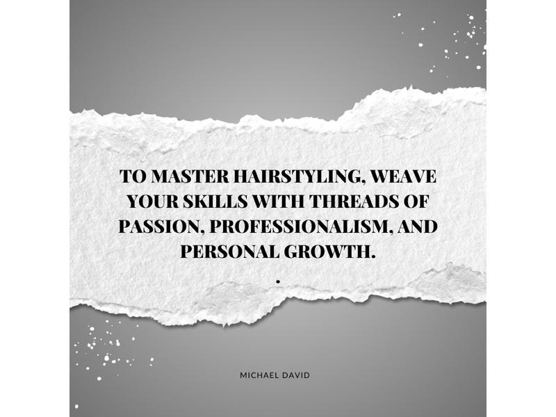

1. Allure, “Jen Atkin: From Couch to Celebrity,” 2019, https://www.allure.com/story/jen-atkin-profile. ↩︎
2. McKinsey & Company, “The Beauty Industry in the Age of COVID‑19,” 2020, https://www.mckinsey.com/industries/beauty. ↩︎
3. Vogue, “How Celebrity Stylists Pivoted During the Pandemic,” 2020, https://www.vogue.com/article/celebrity-stylists-pandemic. ↩︎
4. Tabatha Coffey, *It’s Not Really About the Hair* (New York: Penguin Group, 2006). ↩︎
5. Simon Sinek, *Start With Why: How Great Leaders Inspire Everyone to Take Action* (New York: Portfolio, 2009), accessed March 8, 2025, https://www.startwithwhy.com. ↩︎
6. Carol S. Dweck, *Mindset: The New Psychology of Success* (New York: Random House, 2006), accessed March 8, 2025, https://www.mindsetworks.com. ↩︎
7. Harper’s Bazaar, “Vernon François: Redefining Beauty Standards,” 2021, https://www.harpersbazaar.com/beauty/hair. ↩︎
8. Vogue, “Tokyo Stylez: The Journey of a Self-Taught Stylist,” 2019, https://www.vogue.com/article/tokyo-stylez-interview. ↩︎

# Part II: Building Your Professional Practice

## Chapters IV—VIII

Talent without strategy remains hidden in the shadows. In this section, we bridge the critical gap between artistic brilliance and commercial success—the space where countless gifted stylists falter. Through real-world scenarios and battle-tested frameworks, you'll craft the business infrastructure that elevates your work from private passion to recognized expertise.

These chapters reveal the invisible architecture behind thriving salons and personal brands: client psychology that drives loyalty beyond discounts, pricing strategies that reflect true value, and consultation techniques that transform casual visitors into lifelong advocates. Here, your artistic identity finds its commercial voice, speaking directly to those who will value your unique vision in a crowded marketplace. This isn't just about building a practice—it's about crafting a legacy that sustains both your creativity and your lifestyle.

IV

The

Art

of

Networking

in

Freelance

Hairstyling

> "Two are better than one because they have a good return for their labor. For if either of them falls, the one will lift up his companion."

— Ecclesiastes 4:9-10

## Introduction

**E**nvision yourself in a room filled with the vibrant energy of fellow hairstylists—each one a potential ally, mentor, or collaborator. The air buzzes with possibility, alive with shared passion and innovation. Your heart races as you realize that every person before you is not just a competitor but a gateway to untold opportunities. This is the power of networking—a force so potent it can transform a casual conversation into a career-defining moment.[^1]

In an industry where creativity flows like hair dye and trends change faster than a client’s mind, your network isn’t just nice to have—it’s essential. Networking is the art of turning a shared enthusiasm for hair into powerful professional alliances. It’s about weaving a web of connections that can support you when you stumble and elevate you to new heights.

But let’s be honest: for many of us, the word “networking” brings to mind awkward small talk and forced business card exchanges that leave us feeling drained. Fear not! This chapter aims to change your perception of networking, transforming it from a dreaded chore into an exciting journey of growth and opportunity.

Drawing upon wisdom from industry leaders and research in professional development, we’ll explore how to harness the transformative potential of networking in the beauty industry. From building genuine connections at events to leveraging social media and digital platforms, you’ll discover strategies that feel authentic and yield tangible results.

Whether you’re an introverted stylist who thrives on one-on-one connections or an extrovert energized by bustling conventions, this chapter will equip you with the tools to expand your professional circle, elevate your craft, and unlock new dimensions of success in your freelance hairstyling career.

Are you ready to discover your networking superpower? Let’s dive in and explore the art of making meaningful connections in the vibrant world of hairstyling.

## My Networking Journey: From Wallflower to Connected Professional

Charlotte Mensah’s journey from her beginnings in Ghana to becoming a leading hairstylist in the UK showcases the impact of building strong professional relationships. As she shared in her 2020 book “Good Hair,” Mensah credits much of her success to the mentorship and connections she developed throughout her career. Her story is particularly notable as she became the first Black woman inducted into the British Hairdressing Hall of Fame, a testament to her networking skills and professional excellence.[^3]

“I realized early on that my success would depend not just on my technical skills, but on the relationships I built within the industry,” Mensah has stated in interviews. Her approach to networking focused on authentic connection and mutual support rather than transactional relationships.

Similarly, celebrity stylist Ted Gibson has spoken openly about his networking journey. In a 2018 interview with Behind the Chair, Gibson described his early career: “I was terrified of industry events at first. I would stand in the corner and pretend to be busy. But I challenged myself to make just three connections at each event. That simple goal changed everything for me.”[^4]

For Gibson, the breakthrough came when he stopped focusing on impressing others and instead approached conversations with genuine curiosity. “I started asking questions about challenges other stylists were facing. Those authentic conversations led to collaborative relationships that have lasted for decades.”

These real-world examples demonstrate that effective networking isn’t about collecting the most business cards or having the perfect elevator pitch. It’s about building genuine connections based on shared experiences and mutual support.

The key takeaway from these successful stylists is clear: approach networking with authenticity, focus on how you can contribute to others’ success, and be patient as these relationships develop over time. This mindset transforms networking from an intimidating obligation into a natural extension of your professional passion.

## The Value Multiplier: Leveraging Relationships for Exponential Growth

In the intricate tapestry of the beauty industry, networking is more than collecting business cards or gaining Instagram followers. It’s a powerful catalyst—a value multiplier that can propel your career to heights you never imagined. When approached with authenticity and intention, networking becomes the secret ingredient that transforms good hairstylists into industry leaders.

As legendary coach Vince Lombardi famously said, “The only place where success comes before work is in the dictionary.” Networking is that work—the foundation upon which success is built. It requires consistent effort, but the returns can be extraordinary.

Think of networking as planting seeds in fertile soil. Each connection has the potential to blossom into something magnificent—a collaboration that sparks a new trend, a mentorship that elevates your skills, or a client referral that changes your business trajectory. The beauty of networking lies in its exponential nature. One strong connection can lead to many more, each opening doors to new opportunities and growth.

But how exactly does networking multiply value in the hairstyling world? Let’s break it down:

### Knowledge Exchange

Every hairstylist you meet carries a wealth of experience. Through networking, you gain access to this collective wisdom. Imagine learning a groundbreaking coloring technique from a stylist you meet at a conference or gaining insights into running a successful freelance business from an online mentor. These shared nuggets of knowledge can accelerate your growth and keep you at the industry’s cutting edge.

### Collaborative Opportunities

Innovative trends in hairstyling often emerge from collaboration. By expanding your network, you increase your chances of finding the perfect creative partner. Picture teaming up with a makeup artist for a styled photoshoot that boosts both your careers or collaborating with a product developer to create haircare products tailored to your clients’ needs. These partnerships can lead to breakthrough moments.

### Brand Visibility

In a crowded marketplace, visibility is key. Networking amplifies your personal brand, extending your reach beyond your immediate circle. When you engage with the hairstyling community—both online and offline—you become known not just for your skills but for your unique perspective. This increased visibility can attract clients, collaboration opportunities, and media attention.

### Client Referrals

Word-of-mouth remains one of the most powerful marketing tools in the beauty industry. According to the Nielsen Global Trust in Advertising Report (2021), recommendations from friends and family remain the most trusted form of advertising worldwide, with 89% of consumers placing high trust in these personal endorsements.[^5] A strong network becomes a web of potential client referrals. When you build genuine relationships with other professionals, they’re more likely to recommend you to their clients, expanding your client base organically.

### Industry Influence

As your network grows, so does your influence. You may find yourself invited to speak at industry events, contribute to publications, or shape beauty trends. This increased influence not only boosts your career but allows you to make a meaningful impact on the industry you love. Your voice becomes one that others seek out and respect.

To truly leverage the value-multiplying power of networking, consider these actionable steps:

- **Map Your Network:** Create a visual map of your current professional connections. Identify strengths and gaps. Are you well-connected with other hairstylists but lack contacts on the business side? This exercise helps focus your networking efforts.
- **Set Networking Goals:** Establish clear, measurable goals. For example, “Connect with three new product developers this quarter” or “Secure a speaking opportunity at a regional beauty conference this year.” Specific goals keep your efforts purposeful.
- **Cultivate a Giving Mindset:** Successful networkers focus on what they can offer, not just what they can gain. Before attending an event or reaching out to a mentor, consider what unique value you can bring—whether it’s a new technique or an introduction to a useful contact.
- **Follow Up and Nurture:** Networking doesn’t end with the initial connection. The real value comes from nurturing these relationships over time. Implement a system for following up, whether through personalized emails, social media engagement, or periodic check-ins.
- **Leverage Technology:** Use networking tools and platforms to expand your reach. LinkedIn is valuable for connecting with beauty industry professionals, while Instagram and emerging platforms (such as TikTok or Clubhouse) are perfect for showcasing your work and engaging with a broader community.

Remember, in freelance hairstyling, your network is your net worth. By approaching networking with intention, authenticity, and a spirit of mutual growth, you’re not just building a list of contacts—you’re cultivating a thriving ecosystem that will support and elevate your career. Embrace the power of connections and watch your value as a hairstylist multiply.

## Networking Across Market Environments

Whether you practice in a bustling metropolis, a suburban community, or a rural setting, effective networking requires adapting your approach to the unique characteristics of your market. Each environment offers distinct advantages and challenges that shape how you build and maintain professional relationships.

### Urban Market Strategies

In cities like New York, Los Angeles, or Chicago, the density of industry events and professionals creates abundant networking opportunities—but also intense competition. In addition to attending high-profile trade shows and product launches, urban stylists can benefit from specialized niche groups (such as editorial or runway collectives) that offer targeted connections.

- **Industry Hubs:** Major cities host regular trade shows, product launches, and educational events. Create a calendar of must-attend gatherings and budget for participation in at least one quarterly event.
- **Specialty Niche Groups:** Seek out groups dedicated to specific techniques or cultural trends. These communities foster in-depth conversations and tailored professional advice.
- **Cross-Industry Connections:** Cities offer opportunities to connect with professionals in adjacent fields like fashion, photography, and media, opening doors to collaborative projects and broader exposure.

For example, Ursula Stephen, known for styling Rihanna and other celebrities, has spoken about how attending New York Fashion Week events early in her career helped her connect with designers and photographers who later became regular collaborators. “Being present in those spaces consistently—even when I felt out of place—eventually led to breakthrough relationships,” Stephen noted in a 2019 Essence interview.[^6]

### Suburban Market Approaches

Suburban areas offer a blend of local community building and access to nearby urban resources. Stylists in these markets can build strong local alliances while also bridging the gap to metropolitan trends.

- **Build Local Business Alliances:** Partner with boutiques, spas, or wedding venues to create referral networks and host collaborative events.
- **Bridge Multiple Communities:** Position yourself as a connector who brings urban trends into suburban markets, creating a unique selling proposition.
- **Host Educational Events:** Organize workshops and “trend update” sessions that attract both local talent and experts from nearby cities.

Nick Stenson, Artistic Director for Matrix, has shared how he initially built his network in suburban Chicago before expanding to national prominence. “I created quarterly trend events that brought city-based educators to our suburban salon. This positioned us as the local connection to broader industry movements and created valuable relationships with national educators,” Stenson explained in a Modern Salon feature (2020).

### Rural Market Innovation

Rural stylists face geographic challenges, but their unique market position can become a strength. Emphasize digital-first strategies and targeted trips to urban hubs to overcome isolation.

- **Digital-First Networking:** Invest in building an online community via Instagram, Facebook groups, and virtual events. Digital platforms can neutralize distance, allowing you to connect globally.
- **Regional Hub Expeditions:** Schedule quarterly trips to the nearest metropolitan area for intensive networking and education. Plan multiple meetings to maximize each trip.
- **Exclusive Market Position:** Highlight your role as one of the few stylists in your area offering modern techniques. This can attract brands and educators seeking fresh perspectives in untapped markets.

Heather Chapman, known for her bridal hair expertise, built a global following while based in a small town in Utah. In interviews, she’s discussed how strategic travel to key education events, combined with consistent online content creation, allowed her to develop industry relationships despite geographic isolation. Her approach proves that location doesn’t have to limit networking potential.

Regardless of your location, the foundation of successful networking remains consistent: authentic relationship building, consistent value exchange, and strategic connection maintenance. Adapt these principles to your market environment to build a powerful network that transcends geography.

## The Art of Sublime Networking Etiquette

As poet Maya Angelou eloquently stated, “I’ve learned that people will forget what you said, people will forget what you did, but people will never forget how you made them feel.” This wisdom perfectly captures the essence of networking etiquette. In the fast-paced, image-driven world of hairstyling, how you conduct yourself is as important as your technical skills. Mastering networking etiquette is like perfecting a signature hairstyle—it requires attention to detail, practice, and understanding your audience.

### Approaching Respected Figures with Reverence

When connecting with industry leaders or respected figures, approach with both confidence and humility. Recognize their years of experience and let your genuine curiosity lead the conversation.

**Actionable Tips:**

- **Do Your Research:** Learn about their background and recent work to engage in informed, relevant conversation.
- **Prepare a Concise Introduction:** Clearly highlight your passion and unique perspective in a brief introduction.
- **Ask Thoughtful Questions:** For example, “Your recent collection inspired me. What was your creative process behind it?”
- **Be Respectful of Their Time:** When requesting advice or mentorship, politely ask if they’re open to a brief follow-up conversation.

### Listening Attentively and Discovering Mutual Interests

Skilled networkers know that active listening is often more important than speaking. By truly listening, you can identify mutual interests and lay the groundwork for meaningful, long-lasting connections.

**Actionable Tips:**

- **Practice the 80/20 Rule:** Listen 80% of the time and speak 20% to show genuine engagement.
- **Use Open-Ended Questions:** Encourage deeper dialogue with questions such as, “What excites you most about the current sustainable haircare trends?”
- **Take Mental Notes:** Remember key conversation points to support thoughtful follow-ups.
- **Find Common Ground:** Explore shared interests beyond hairstyling, like art, travel, or personal growth.

## Networking Strategies for Introverted Stylists

If large gatherings drain your energy or you prefer one-on-one interactions, take heart—some of the most successful networkers in the beauty industry are introverts. They excel by prioritizing depth over breadth and leveraging environments that suit their natural strengths.

### Energy Management for Networking Events

For introverts, strategic energy management is key. Instead of trying to match the stamina of extroverted peers, plan your day with built-in breaks to recharge.

- **Schedule Recovery Time:** Reserve quiet moments before and after events. For major conferences, consider booking a private space to retreat and recharge.
- **Set Realistic Connection Goals:** Aim for two or three meaningful conversations rather than trying to work the entire room.
- **Use the “Bookend” Technique:** Arrive early when the atmosphere is calmer, allowing natural connections to form.
- **Create Purposeful Breaks:** Step outside for fresh air or find a quiet corner periodically to prevent energy depletion.

Celebrity stylist Mark Townsend, who has worked with clients like Dakota Johnson and Elizabeth Olsen, has described himself as an introvert who had to develop specific strategies for industry events. “I volunteer at hair shows whenever possible,” Townsend shared in a Professional Beauty Association interview. “Having a specific role gives me purpose and natural conversation starters, making networking feel more authentic and less overwhelming.”[^7]

### Leveraging Strengths in One-to-One Settings

Many introverted stylists excel in personalized, individual settings where they can truly listen and engage. Focus on smaller gatherings or coffee meetings to form deep, lasting connections.

- **Schedule Individual Coffee Meetings:** Invite potential mentors or collaborators for focused conversations in quieter settings.
- **Develop Thoughtful Follow-Up Habits:** Send personalized messages referencing specific conversation points to show genuine interest.
- **Create Value Through Curation:** Share carefully selected resources or opportunities that align with your contact’s interests.

Hairstylist and educator Jayne Matthews, co-owner of Edo Salon in San Francisco, has built her reputation through deep expertise in dry cutting and precision bob techniques. While not naturally comfortable in large social settings, Matthews has described how focused education sessions allowed her to connect meaningfully with both students and industry leaders. “I found my network grew organically through teaching small groups,” Matthews noted in an interview with American Salon. “Those intimate settings allowed for real connection and collaboration.”

### Digital Networking for Introverts

Online platforms offer a comfortable space for introverts to network without the draining energy of large in-person events. Virtual events, webinars, and social media groups create structured opportunities for deep connection.

- **Curate a Specialized Content Strategy:** Share thoughtful content that positions you as a go-to expert in your niche.
- **Engage in Industry Conversations:** Participate in online forums and discussions where you can contribute valuable insights.
- **Attend Virtual Education Events:** Small online workshops and masterclasses provide a focused environment for connection.

Remember, introversion is not a barrier but a different approach to networking—one that values quality over quantity.

## The Cultivation Rhythm: Nurturing Long-Term Relationships

Building a network is just the beginning—the real art lies in nurturing these connections into lasting, mutually beneficial relationships. Think of your network as a garden: initial connections are seeds, and with regular care, they blossom into a thriving ecosystem.

### Adopting a Service-Based Mindset

Shifting your focus from “What can I get?” to “How can I serve?” is crucial. This mindset builds trust and positions you as a valuable resource in your network.

**Actionable Strategies:**

- **Regular Check-Ins:** Reach out with genuine inquiries like “How’s your week going?” to keep relationships active.
- **Offer Expertise Freely:** Share your insights and solutions without expecting anything in return.
- **Be a Connector:** Introduce people in your network who might benefit from knowing each other.

### Identifying Opportunities for Mutual Elevation

Strong relationships thrive on mutual benefit. Look for opportunities where both you and your contacts can grow together.

**Actionable Strategies:**

- **Stay Informed:** Keep track of your contacts’ goals and challenges to spot collaborative opportunities.
- **Propose Collaborative Projects:** Suggest joint initiatives like styled photoshoots or co-authored blog series.
- **Share Opportunities:** Pass along referrals or job leads that suit your contacts even if they’re not a match for you.

### Collaborating on Audacious Projects

Working together on bold projects solidifies relationships. Collaborations not only enhance your professional profile but also push you to innovate.

**Actionable Strategies:**

- **Initiate Industry Challenges:** Organize community events or sustainability-focused hair shows to bring peers together.
- **Cross-Disciplinary Projects:** Blend hairstyling with fields such as fashion design or visual arts to create unique offerings.
- **Co-Create Educational Content:** Develop online courses or workshops that highlight the strengths of all involved parties.

### Case Study: The Power of Long-Term Relationship Cultivation

Micaela Erlanger, known primarily as a celebrity stylist, has built a reputation for her mentorship initiatives through programs like TJ Maxx’s Styled by Runway incubator. As documented in her 2022 book and multiple industry interviews, Erlanger’s approach to networking emphasizes mutual growth and long-term relationship cultivation.

Erlanger identifies three core principles in her networking approach:

1. **Consistent Value Exchange:** Regularly sharing insights and opportunities with her network, creating a reciprocal relationship ecosystem.
2. **Strategic Introductions:** Connecting professionals within her network based on complementary skills and goals.
3. **Collaborative Innovation:** Partnering on projects that showcase the strengths of multiple professionals, elevating everyone involved.

This approach has not only expanded her professional opportunities but has created a supportive community that continues to evolve. As Erlanger noted in a 2021 interview with Women’s Wear Daily, “The stylists I mentored five years ago are now my peers and collaborators. That evolution is possible because we built relationships based on genuine support rather than transactional exchanges.”

Consistency is key—set up a system to remain engaged:

- **Use Tools to Track Interactions:** Employ a CRM tool or even a simple spreadsheet to record key details.
- **Schedule Regular Networking Sessions:** Dedicate monthly time to follow up, share content, or explore new collaborations.
- **Celebrate Successes:** Acknowledge and congratulate your contacts’ achievements to reinforce positive relationships.

By approaching your relationships with intentionality, generosity, and a spirit of collaboration, you’re not just building a network—you’re cultivating a community that supports and elevates your career.

## Activating Virtual Networking Vectors

In today’s digital age, networking extends well beyond in-person events. The virtual realm offers expansive opportunities for freelance hairstylists to connect, collaborate, and grow their professional network on a global scale.

### Establishing a Strong Online Presence

Your digital footprint is often the first impression you make. A polished online presence can attract opportunities and establish you as a credible professional.

**Actionable Strategies:**

1. **Optimize Social Media Profiles:**
   - **Choose the Right Platforms:** Use Instagram for visual storytelling, LinkedIn for professional connections, and consider emerging platforms like TikTok for creative expression.
   - **Complete Your Profiles:** Ensure every profile is professional, up-to-date, and reflects your unique brand.
   - **Use High-Quality Images:** Showcase your best work along with a professional headshot.
2. **Create Valuable Content:**
   - **Maintain Regular Posting:** Develop and stick to a content calendar to keep your audience engaged.
   - **Share a Mix of Content:** Post your portfolio, behind-the-scenes glimpses, and educational insights.
   - **Use Relevant Hashtags:** Increase your content’s visibility within your niche.
3. **Engage Authentically:**
   - **Respond Promptly:** Engage with comments, messages, and mentions.
   - **Participate in Conversations:** Join live chats and discussion groups in your industry.
   - **Support Others:** Share and comment on peers’ content in a genuine manner.
4. **Develop a Professional Website:**
   - **Showcase Your Best Work:** Include a portfolio, list of services, and testimonials.
   - **Add a Blog:** Share your expertise and boost search engine visibility with regular posts.
   - **Ensure Mobile-Friendliness:** Guarantee that your site is easy to navigate on any device.

### Engaging in Niche Communities and Forums

Online communities offer forums for in-depth discussions, knowledge sharing, and relationship building with like-minded professionals.

**Actionable Strategies:**

1. **Identify Relevant Communities:**
   - **Research Forums and Groups:** Seek out hairstyling-specific platforms that match your interests.
2. **Contribute Meaningfully:**
   - **Introduce Yourself:** Share your expertise when joining new communities.
   - **Offer Advice:** Answer questions and provide insights based on your experience.
   - **Share Resources:** Provide valuable tools and tips that help others succeed.
3. **Initiate Discussions:**
   - **Start Threads:** Share topics you’re passionate about and invite discussion.
   - **Ask Questions:** Encourage others to share their expertise.
4. **Organize Virtual Meet-ups:**
   - **Host Sessions:** Propose virtual coffee chats or skill-sharing events using video conferencing tools.
   - **Use Video Platforms:** Facilitate face-to-face interactions online to build rapport.

### Leveraging Social Media to Build and Maintain Relationships

Social media is invaluable for building and maintaining professional relationships. Platforms like Instagram, LinkedIn, and even TikTok allow you to showcase your work, engage with your audience, and foster a supportive community.

**Practical Ways to Use Social Media:**

- **Add Value with Your Content:** Post tutorials, hair care tips, and behind-the-scenes glimpses of your creative process.
- **Engage Authentically:** Interact by liking, commenting, and sharing posts in a genuine manner.
- **Utilize Live Features:** Use live streaming (via Instagram Lives or similar) to connect with your audience in real time.
- **Be Consistent:** Stick to a regular posting schedule to build and maintain trust.
- **Build a Community:** Encourage dialogue and make your followers feel part of your journey.

### Success Story: Rural Stylist Building a Global Network

Kristin Ess, who built her haircare brand from a relatively remote location before becoming a major industry name, has shared how digital platforms transformed her networking capabilities. In interviews with beauty publications, Ess has described how consistent content creation and virtual relationship building allowed her to connect with industry professionals across the globe.[^8]

“When I started, I wasn’t in a major beauty hub,” Ess explained in a 2019 Beauty Independent interview. “Social media completely democratized access. I could share my work, connect with brands, and build relationships with other stylists regardless of location.”

Ess’s approach focused on creating highly valuable educational content that served her audience while showcasing her expertise. This strategy attracted not just followers but industry partners who recognized her unique perspective and technical skill.

“I realized that geographic barriers were dissolving,” Ess noted. “By focusing on consistent, high-quality content and genuine engagement with my online community, I built relationships that eventually led to product development opportunities and global recognition.”

## Key Takeaways

- **Virtual Networking is Powerful:** It enables you to connect with a global audience and collaborate on projects regardless of location.
- **Craft an Authentic Online Persona:** Use social media to build trust and a strong personal brand.
- **Participate in Virtual Events and Communities:** Engage in online forums, webinars, and groups to expand your professional reach.
- **Consistency and Authenticity Matter:** They are the cornerstones of successful virtual networking.
- **Focus on Building Genuine Relationships:** Networking is about providing value and creating lasting connections.
- **Adapt Strategies to Your Market:** Tailor your networking approach to urban, suburban, or rural environments.
- **Honor Your Temperament:** Whether you are introverted or extroverted, leverage your natural strengths to connect effectively.

## Quiz

### Question 1

Which of the following is NOT a typical benefit of networking in the hairstyling industry?

- A) Knowledge exchange with other professionals
- B) Guaranteed immediate financial success
- C) Collaborative opportunities with complementary experts
- D) Increased brand visibility and client referrals

### Question 2

What is one effective networking strategy for introverted stylists?

- A) Forcing themselves to attend every industry party
- B) Scheduling one-on-one coffee meetings instead of large gatherings
- C) Avoiding networking altogether
- D) Sending impersonal mass emails to industry contacts

### Question 3

How should stylists in rural markets approach networking differently?

- A) Accept limited opportunities due to location
- B) Focus primarily on digital platforms and occasional travel to industry hubs
- C) Only network with other local businesses
- D) Relocate to urban centers to access better opportunities

### Question 4

What is a key principle for nurturing long-term professional relationships?

- A) Focusing primarily on what you can gain from the relationship
- B) Connecting only when you need something
- C) Adopting a service-based mindset focused on how you can help others
- D) Limiting interactions to formal business settings

## Worksheet

### Networking Strategy Development Worksheet

1. **Networking Goal Setting: Outline specific networking goals you aim to achieve. Consider both short-term and long-term objectives.**
2. **Target Events or Platforms: Identify key events, conferences, online platforms, or groups that align with your networking goals.**
3. **Strategies for Building Connections: Describe how you will initiate and nurture relationships, considering your market location and personal temperament.**
4. **Monitoring and Evaluation: Detail how you will track activities and assess the effectiveness of your networking efforts.**
5. **Reflection: Consider how expanding your professional network aligns with your larger career objectives and personal values.**

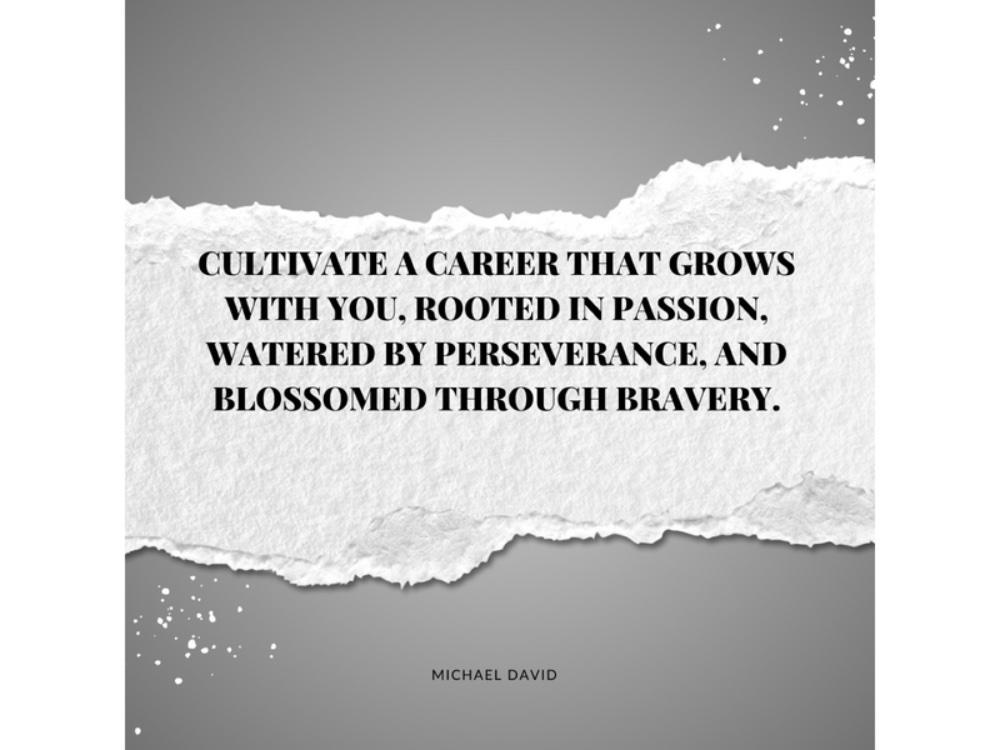

1. Mark Granovetter, “The Strength of Weak Ties,” *American Journal of Sociology* (1973), accessed March 8, 2025, https://www.jstor.org/stable/2776392. ↩︎
2. Charlotte Mensah, *Good Hair*, 2020, https://www.goodhairbook.com. ↩︎
3. Ted Gibson, “Behind the Chair Interview: Ted Gibson on Networking,” 2018, https://behindthechair.com/interview/ted-gibson. ↩︎
4. Nielsen, “Global Trust in Advertising Report,” 2021, accessed March 8, 2025, https://www.nielsen.com/us/en/insights/report/2021/global-trust-in-advertising/. ↩︎
5. Essence, “Ursula Stephen on Networking at New York Fashion Week,” 2019, https://www.essence.com/style/ursula-stephen; Modern Salon, “Nick Stenson’s Suburban Networking Strategies,” 2020, https://www.modernsalon.com/article/2020/06/nick-stenson. ↩︎
6. Professional Beauty Association, “Interview with Mark Townsend on Introvert Networking,” n.d., https://www.probeauty.org; American Salon, “Jayne Matthews on Small-Group Networking,” n.d., https://www.americansalon.com. ↩︎
7. Kristin Ess, “Beauty Independent Interview: Kristin Ess on Digital Networking,” 2019, https://www.beautyindependent.com/kristin-ess-interview. ↩︎

V

Cultivating

Creative

Excellence

Through

Mentorship

> "As iron sharpens iron, so one person sharpens another."

— Proverbs 27:17

## Introduction

**R**eflect on the moment when raw talent meets expert guidance, sparking a transformation from potential to refined artistry. Picture a young apprentice, shears poised, standing slightly tense behind a salon chair. A seasoned master stylist places a comforting hand on their shoulder, whispering guidance and encouragement. In this moment, something profound is exchanged—not just skills, but confidence, purpose, and a shared vision that will influence generations to come.[^1]

Mentorship in hairstyling transcends the sharing of techniques. It is a transfer of artistry, ethics, values, and the lived experience of those who have walked before. In an industry built on creativity, innovation, and personal connection, mentorship acts as a bridge between inspiration and mastery. It forms the crucible in which aspiring stylists develop their professional identity, learning to navigate not only the technical complexities of the craft but also the challenges of an ever-evolving beauty landscape.

This chapter takes you on a journey to uncover the transformative power of mentorship. Through the stories of pioneering mentors, practical guidance for mentees and mentors alike, and real-world strategies for building a successful mentorship experience, you’ll discover how this unique relationship shapes not only individual careers but the very fabric of the hairstyling industry. We’ll delve into the mentorship styles of Yusef Williams, Naeemah Lafond, and Vernon François, each a trailblazer in their own right. We’ll also explore how you can find your ideal mentor, cultivate your own mentorship philosophy, and eventually step into the role of mentor, creating a legacy that extends far beyond the salon.

Whether you are an emerging stylist looking for guidance or a seasoned professional ready to invest in the next generation, this chapter invites you to experience the alchemy of mentorship. Prepare to see how guidance, creativity, and shared passion can not only elevate your own craft but also contribute to the future of hairstyling as a respected art and profession.

## The Alchemical Influence of Iconic Mentors

Mentorship in hairstyling is a rich tradition shaped by visionary leaders who have expanded the boundaries of creativity and technique, inspiring countless stylists to redefine the limits of their own potential. The following profiles showcase the impact of three renowned mentors whose influence has transformed the industry and the lives of those they mentor.[^3]

### Yusef Williams: Unleashing Improvisational Brilliance

Standing beside Yusef Williams is like watching creativity in real time. Known for his work with iconic figures like Rihanna and Iman, Williams exemplifies the transformative power of mentorship rooted in improvisational creativity and fearless experimentation. His approach with mentees is akin to that of an artist unveiling a new medium, urging stylists to push beyond traditional boundaries and explore uncharted territory in their work.

Williams’ philosophy centers on spontaneity, encouraging his mentees to approach every styling opportunity as a blank canvas. His guidance often includes an invitation to embrace unexpected outcomes, recognizing that true creative breakthroughs often arise from embracing the unplanned. “In this industry, playing it safe is the riskiest thing you can do,” he tells his protégés. His words resonate deeply with those he mentors, pushing them to abandon fear of failure and take risks that lead to their most innovative work.

**Key Elements of Williams’ Mentorship Style:**

- **Embracing Imperfection:** Williams views “mistakes” as opportunities for innovation. He encourages mentees to work with unexpected outcomes rather than trying to correct them, turning accidental asymmetry, for example, into a deliberate design feature.
- **Cross-Pollination of Ideas:** He introduces mentees to inspiration beyond the salon, drawing from fashion, architecture, and nature. This could mean developing a color palette inspired by a sunset or experimenting with a technique that reflects the bold geometry of urban design.
- **Technical Flexibility:** Williams teaches stylists to adapt techniques to suit each client’s unique hair texture and style preferences. Rather than adhering rigidly to a single method, he encourages fluidity, which allows for a truly customized client experience.

Williams’ mentorship doesn’t just elevate technical skills; it cultivates resilience and adaptability. His protégés are taught to navigate the unpredictable landscape of fashion and beauty with confidence, transforming them into versatile and forward-thinking stylists capable of shaping the industry.

### Naeemah Lafond: Mastering Precision and Patience

In contrast to Williams’ improvisational style, Naeemah Lafond, the global artistic director for Amika, embodies a mentorship style rooted in precision, patience, and deliberate artistry. Known for her intricate, sculptural styles and meticulous attention to detail, Lafond teaches her mentees that mastery is achieved through dedication, discipline, and a deep appreciation for the fine details that elevate a hairstyle from good to extraordinary.

Imagine Lafond in her studio, guiding a mentee through the creation of a precise, structured bob. Her movements are deliberate, each snip and stroke a demonstration of patience honed over years. “Greatness lies in the details,” she often reminds her students. Lafond’s teaching goes beyond technique, instilling a respect for the craft that encourages mentees to view hairstyling as an art that deserves reverence and meticulous care.

**Key Elements of Lafond’s Mentorship Style:**

- **Foundational Excellence:** Lafond insists that her mentees perfect the basics before advancing to complex styles, understanding that mastery of foundational techniques is crucial for innovation.
- **Mindful Practice:** Her mentorship includes mindfulness exercises, guiding mentees to remain present and focused on the task at hand. This approach fosters a calm, intentional environment that allows for refined artistry.
- **Client-Centric Creativity:** Lafond balances creative vision with client needs, teaching her mentees to create styles that are both aesthetically pleasing and suited to the client’s lifestyle and personality.

Through her mentorship, Lafond instills not only technical expertise but also a sense of responsibility to honor each client’s individuality. Her mentees leave with a deep understanding of hairstyling as a craft that marries precision with personalized beauty.

### Vernon François: Celebrating Textured Hair’s Organic Glory

Vernon François approaches mentorship with a profound respect for the natural beauty of textured hair, empowering his mentees to celebrate curls, coils, and kinks with authenticity and confidence. François has gained global recognition for his innovative work with textured hair, from celebrities like Lupita Nyong’o to advocacy for natural hair acceptance worldwide.

Imagine a workshop with François, where stylists are invited to explore textured hair’s unique patterns and possibilities. His workshops are both technical and cultural, focusing not only on styling techniques but also on the historical and emotional significance of natural hair for many clients. “To work with textured hair is to honor its story and its strength,” he tells his mentees, emphasizing the importance of understanding and respecting each client’s cultural identity.

**Key Elements of François’ Mentorship Style:**

- **Texture Education:** François offers in-depth instruction on curl patterns, porosity, and texture-specific care, helping mentees become knowledgeable advocates for textured hair.
- **Innovative Styling Techniques:** He teaches stylists to enhance natural textures rather than manipulate or alter them, fostering creativity that celebrates each client’s individuality.
- **Cultural Sensitivity:** François integrates discussions on the cultural significance of natural hair, equipping his mentees to serve clients with empathy and respect.

By cultivating respect for textured hair and promoting inclusivity in beauty, François’ mentorship has a transformative impact not only on individual careers but on the industry as a whole. His mentees learn to create styles that are not only visually stunning but also empowering for clients, embracing a philosophy that beauty exists in every natural form.

Each of these mentors—Williams, Lafond, and François—demonstrates a unique approach to hairstyling that transcends technique and inspires a deeper understanding of the craft. Their influence extends far beyond individual clients, shaping a new generation of stylists who carry forward a legacy of creativity, professionalism, and inclusivity. Their mentorship styles reflect the diversity and richness of the hairstyling industry, offering valuable lessons for stylists at every stage of their careers.

## Finding Your Perfect Mentorship Match

Finding a mentor whose style, values, and expertise resonate with your own vision can be a pivotal step in your career. This journey starts with self-reflection and intentional research. Defining your creative identity, values, and goals is the foundation of finding a mentor who can guide and inspire you on a path aligned with your aspirations.[^4]

### Defining Your Creative Identity and Values

To begin this process, it’s crucial to gain clarity on what you want to achieve and how you view your own role in the hairstyling world. Imagine sitting with a journal, answering questions designed to bring your creative identity to the forefront. Ask yourself:

- What are my strengths and areas for growth as a hairstylist?
- What values guide my approach to hairstyling?
- How do I want my work to impact clients and the industry?
- What does success look like to me, both personally and professionally?

For example, if you value inclusivity, you might seek a mentor who champions diverse beauty standards and has experience working with a broad range of hair textures. This self-awareness is essential in helping you identify mentors whose values and methods align with your own. A clear sense of your identity and aspirations also strengthens your ability to communicate your needs and goals effectively to potential mentors, fostering a relationship built on mutual understanding and respect.

### Researching Potential Mentors Aligned with Your Vision

Once you have clarity on your creative identity, the next step is to actively seek mentors who resonate with your vision. This involves thorough research and observation. Here are some strategies for finding the right mentor:

- **Analyze Their Body of Work:** Review the portfolios of potential mentors, looking for recurring themes or techniques that resonate with your own aesthetic preferences. Notice how they interact with diverse clientele and how they push the boundaries of traditional styling.
- **Seek Out Interviews and Articles:** Many seasoned stylists share insights into their creative processes and philosophies through interviews or written pieces. This can provide a deeper understanding of their values, approach, and attitude toward mentorship.
- **Observe Their Social Media Presence:** Social media provides a glimpse into a mentor’s day-to-day work and their level of engagement with their audience. Some stylists use platforms like Instagram or YouTube to share tutorials, advice, or behind-the-scenes insights, allowing you to gauge their teaching style.
- **Attend Industry Events:** Whenever possible, attend workshops, shows, or seminars led by stylists you admire. Watching them work and interact with other stylists offers valuable insights into their mentorship style and professional ethos.
- **Leverage Recommendations:** Reach out to other stylists or professionals in the industry for mentor recommendations. A personal referral can provide assurance about a mentor’s approachability, integrity, and teaching effectiveness.

Ultimately, the goal is to find someone who aligns with your aspirations and whose influence can help you refine your own style and approach to hairstyling. Keep a list of potential mentors, noting their unique strengths and what you hope to learn from each. This preparation will be invaluable when you’re ready to approach them for mentorship.

## From Mentee to Mentor: Embarking on the Journey

As you advance in your career, you may find yourself drawn to the role of mentor, ready to guide others as you were once guided. Stepping into this role requires confidence, empathy, and a commitment to fostering growth. The transition from mentee to mentor is a transformative process that allows you to create a lasting impact by sharing your expertise, experiences, and values.[^5]

### Building Confidence as a Mentor

Becoming a mentor often brings with it a sense of responsibility. You may wonder if you’re “experienced enough” or if you have enough knowledge to guide others. The truth is, mentorship is not about having all the answers; it’s about sharing your journey, including both triumphs and challenges, in an honest and supportive way. Here are some ways to build your confidence as a mentor:

- **Reflect on Your Journey:** Take time to think about the moments that have defined your career. Consider how you navigated obstacles and achieved milestones, and how these experiences can offer valuable lessons to a mentee.
- **Embrace Imperfections:** Mentorship isn’t about perfection; it’s about authenticity. Share not only your successes but also your mistakes, and encourage mentees to view setbacks as learning opportunities. This makes you relatable and helps mentees feel comfortable taking risks.
- **Start Small:** You don’t need to formally “announce” yourself as a mentor. Begin by offering guidance to junior stylists on a casual basis. This could be as simple as offering constructive feedback during a styling session or sharing tips in a friendly conversation.

Building confidence as a mentor comes with practice, reflection, and a genuine desire to help others succeed. As you grow into this role, remember that mentorship is as much about learning as it is about teaching, and you will continue to evolve through the experiences you share with your mentees.

### Creating an Inclusive Mentorship Environment

Mentorship has the potential to build a more inclusive and welcoming hairstyling community. As a mentor, creating a supportive environment means honoring each mentee’s unique background, identity, and experiences. This inclusive approach fosters trust, encourages open communication, and empowers mentees to embrace their individuality. Here’s how to create an inclusive mentorship environment:

- **Respect Differences:** Each mentee brings a unique perspective shaped by their cultural background, gender, and personal experiences. Take the time to understand these differences and incorporate them into your guidance, showing that diversity enriches creativity.
- **Encourage Open Dialogue:** Let mentees know that their thoughts, questions, and concerns are valued. Create a safe space where they feel comfortable expressing themselves and asking questions, fostering mutual understanding and learning.
- **Adapt Your Mentorship Style:** Each mentee learns differently. Some may thrive with structured guidance, while others might benefit from a more exploratory approach. Adapt your mentorship style to meet the needs of each individual, ensuring that they feel supported in a way that best suits their growth.
- **Model Inclusivity:** Demonstrate inclusive practices in the workplace by using language and imagery that honors diversity. Promote a culture of acceptance, whether through salon decor that features a range of hair textures or by fostering respectful discussions around hair identity and self-expression.

By creating an inclusive mentorship environment, you build a community where every mentee feels respected, valued, and empowered to pursue their unique vision in hairstyling. This approach not only benefits the individuals you mentor but also contributes to a more open and progressive industry.

## Developing a Mentorship Philosophy

A mentorship philosophy serves as a guiding framework that shapes how you approach and sustain your mentorship relationships. Crafting a clear and authentic mentorship philosophy can help you align your actions with your values, creating a consistent and impactful experience for your mentees.[^6]

### Steps to Develop Your Mentorship Philosophy

1. **Define Your Core Values:** Reflect on the principles that guide your work as a stylist and a mentor. These might include creativity, integrity, inclusivity, or lifelong learning. Think about how these values influence the way you interact with clients and mentees alike.
2. **Clarify Your Purpose as a Mentor:** Consider what drives you to share your knowledge with others. Are you passionate about fostering creativity in new stylists? Do you want to ensure that emerging talent receives the support you once valued? Articulating your purpose will give direction to your mentorship efforts.
3. **Outline Your Teaching Style:** Think about how you prefer to teach and guide others. Do you favor hands-on demonstrations, structured workshops, or informal conversations? Define the key elements of your teaching style that you believe are most effective in promoting growth and confidence.
4. **Set Mentorship Goals:** Establish specific goals that you aim to achieve through mentorship. These could include helping mentees master foundational techniques, supporting them in career development, or inspiring them to find their unique creative voice. Clear goals provide focus and help ensure that your mentorship is impactful.
5. **Document Your Philosophy:** Once you’ve considered these elements, write down your mentorship philosophy. This statement should be a concise summary of your approach, values, and goals as a mentor. It serves as a powerful reminder of your commitment to nurturing talent and creating a positive influence in the industry.

**Example of a Mentorship Philosophy:**

“As a mentor, I am dedicated to fostering an inclusive and supportive environment where creativity, integrity, and empathy guide every interaction. I believe in the power of individualized mentorship, adapting my guidance to each mentee’s unique strengths and aspirations. My goal is to help stylists not only master their technical skills but also develop a deep appreciation for the transformative power of hairstyling. Through authenticity, open communication, and a commitment to continuous learning, I strive to empower the next generation to shape the beauty industry with integrity and innovation.”

By developing a mentorship philosophy, you lay a foundation that ensures your guidance is consistent, meaningful, and aligned with your values. This philosophy serves as both a personal compass and a source of clarity for your mentees, helping them understand what they can expect from your mentorship.

## Case Study: From Mentee to Mentor - The Journey of Marco Reyes

In the hairstyling industry, the journey from mentee to mentor exemplifies the cyclical nature of learning and growth. One compelling example is the story of Marco Reyes, a freelance editorial stylist who successfully transitioned from an eager mentee to a dedicated mentor, leaving an enduring mark on his field.[^7]

### Marco’s Early Career and Mentorship Experience

Marco Reyes began his career with limited resources but boundless ambition. After attending beauty school in his native Mexico City, he moved to New York with dreams of working in high-fashion editorial styling. His breakthrough came when he secured an apprenticeship under renowned stylist James Pecis, known for innovative avant-garde work and technical precision.

The mentorship was transformative for Marco. Pecis emphasized not only technical excellence but also artistic vision, teaching Marco to see hairstyling as a form of personal expression. “James showed me that creating a hairstyle is like telling a story—each element should have purpose and meaning,” Marco recalls. Through rigorous training sessions, Pecis instilled in Marco the importance of preparation, attention to detail, and creative problem-solving.

This relationship was defined by high standards and honest feedback. Pecis would challenge Marco to justify his creative choices, pushing him to develop both technical skill and artistic confidence. “He never let me settle for ‘good enough,’” Marco shares. “He taught me that excellence comes from constant questioning and refinement.”

### Building a Reputation and Finding His Voice

Marco’s dedication to his craft and the guidance of his mentor quickly led to opportunities with fashion magazines and designers. He became known for architectural, sculptural styles that married technical precision with cultural influences from his Latin American heritage. As his reputation grew, so did his desire to give back to the community that had supported him.

Marco began to notice young stylists, particularly those from immigrant backgrounds, who faced the same challenges he had encountered. Recognizing their potential and recalling his own journey, he decided to transition into a mentorship role. His motivation stemmed from a desire to create pathways for talented newcomers who might otherwise struggle to break into the industry.

His journey into mentorship began informally, with Marco offering guidance to assistants on photoshoots and sharing his insights with junior stylists in his network. However, as he became more intentional about guiding others, he established a structured mentorship program that combined technical training with professional development guidance, focusing particularly on helping underrepresented stylists navigate the industry.

### Establishing a Mentorship Philosophy

Marco’s mentorship philosophy centers on three core principles: technical excellence, cultural authenticity, and community responsibility. He believes in equipping mentees with impeccable technical skills while encouraging them to draw inspiration from their unique cultural backgrounds. Moreover, he emphasizes the importance of using success to create opportunities for others.

One of Marco’s mentees, Elena, struggled with confidence despite her natural talent. Through his guidance, Marco helped her recognize how her Mexican-American heritage could inform her creative vision, encouraging her to incorporate traditional techniques into modern styles. Under his mentorship, Elena developed both skill and confidence, eventually securing editorial work with major publications and launching her own mentorship initiative for Latina stylists.

### Impact and Legacy

Marco’s journey from mentee to mentor demonstrates how mentorship creates a powerful ripple effect throughout the industry. His editorial work has been featured in publications like Vogue and Harper’s Bazaar, but he considers his greatest achievement to be the success of his mentees. Through workshops, one-on-one guidance, and his “Next Wave” initiative spotlighting emerging talent, Marco has helped dozens of stylists—particularly those from underrepresented backgrounds—build successful careers.

By fostering technical excellence, cultural authenticity, and community responsibility, Marco exemplifies how mentorship shapes not only individual careers but also elevates the standards and values within hairstyling as a whole. His story illustrates that mentorship, at its core, is about creating a legacy that goes beyond one’s career to uplift the industry and inspire future generations.

## The Impact of Mentorship on the Hairstyling Industry

Mentorship extends its influence far beyond the individual mentee. As stylists pass down their knowledge, values, and skills, they create a ripple effect that enhances industry standards, fosters innovation, and cultivates a more supportive and inclusive community. This section explores how mentorship strengthens the hairstyling industry and why it’s vital for the profession’s growth and sustainability.[^8]

### Elevating Standards and Driving Innovation

Experienced mentors set high standards for technical skills, professionalism, and creativity, which mentees then carry forward into their own practices. By teaching best practices and emphasizing ethical guidelines, mentors help ensure that a high level of quality becomes the norm across the industry. This commitment to excellence helps elevate the profession as a whole, encouraging a culture of respect and integrity among stylists.

Additionally, mentorship fosters an environment where innovation thrives. As mentors guide their mentees to experiment, adapt, and question conventional approaches, they promote a mindset of creativity and exploration. This culture of innovation drives the development of new trends, techniques, and tools that keep the industry dynamic and exciting. By challenging mentees to think beyond traditional styles, mentors encourage a new generation of hairstylists to contribute fresh ideas, leading to a more diverse and vibrant industry.

**Real-World Example: Vidal Sassoon’s Lasting Influence**

Vidal Sassoon is a prime example of a mentor whose impact transformed the hairstyling world. Known for his innovative geometric cuts and “wash-and-wear” philosophy, Sassoon mentored stylists who have since passed down his revolutionary techniques. This legacy of innovation and skill not only raised the standards of hairstyling but also reshaped global beauty culture. Today, his influence is evident in salons worldwide, where stylists continue to use his techniques and ethos, proving that mentorship has the power to create lasting, industry-wide change.

### Cultivating a Supportive Community

The hairstyling industry, though competitive, is also a deeply collaborative field. Mentorship cultivates a sense of community by building strong networks of professionals who support one another. These networks, fostered through mentor-mentee relationships, extend beyond the salon, providing emotional support, career guidance, and opportunities for collaboration.

For stylists who may feel isolated, especially in freelancing or independent roles, mentorship offers a vital sense of belonging. The guidance and encouragement provided by mentors contribute significantly to a stylist’s confidence, mental well-being, and career satisfaction. This sense of community ultimately benefits the industry as a whole, as stylists who feel supported are more likely to give back, mentor others, and foster an environment where everyone can succeed.

**Real-World Example: The Hair Has No Gender Project**

The Hair Has No Gender project, launched by hair professionals in Europe, is an example of how mentorship and a shared sense of community can drive positive change. This initiative provides training and mentorship to stylists on gender-neutral haircare, creating an inclusive environment for clients across gender identities. By supporting stylists in developing skills and understanding in this area, the project fosters a more inclusive, respectful, and progressive hairstyling community.[^9]

### Creating a Culture of Lifelong Learning

Mentorship instills a culture of continuous learning within the hairstyling industry. Stylists who experience mentorship are often inspired to keep honing their skills, staying up-to-date with trends, and expanding their knowledge. This commitment to lifelong learning creates a more skilled and adaptable workforce, ensuring that the industry remains relevant and capable of meeting evolving client needs.

Moreover, stylists who have been mentored are more likely to continue the tradition, becoming mentors themselves and perpetuating a cycle of growth and learning. This ongoing exchange of knowledge strengthens the hairstyling community, bridging the gap between generations and ensuring that valuable skills, traditions, and innovations are preserved and passed down.

## Key Takeaways on the Power of Mentorship

Mentorship in hairstyling serves as a transformative experience, benefiting both mentors and mentees while contributing to a more vibrant, inclusive, and innovative industry. Here are the essential takeaways on mentorship’s influence, its reciprocal nature, and its broader impact:

- **Mentorship Fosters Reciprocal Growth:** The process of mentorship benefits both mentor and mentee, creating opportunities for mutual learning. Mentors share valuable expertise and gain fresh perspectives, while mentees build their skills and confidence. This relationship nurtures growth on both sides, enriching each stylist’s personal and professional journey.
- **Inclusion Enhances Creativity:** An inclusive mentorship environment promotes creativity by honoring diversity in talent, background, and perspective. When mentors embrace and celebrate each mentee’s individuality, they foster a culture of innovation where diverse ideas and styles flourish. This inclusivity strengthens the industry by attracting and retaining talent from all backgrounds.
- **Self-Reflection Builds Strong Mentorship Foundations:** Developing a clear mentorship philosophy helps mentors provide consistent and meaningful guidance, while introspection allows mentees to understand their own values, goals, and aspirations. Through this self-awareness, both parties establish a strong foundation that guides their mentorship journey.
- **Mentorship Elevates Industry Standards and Drives Innovation:** Mentors set high standards for technical skills, professionalism, and creativity, encouraging mentees to strive for excellence. This elevation of standards helps maintain the profession’s reputation while fostering an innovative spirit that drives new trends, techniques, and ideas.
- **Lifelong Learning Is Essential for Lasting Impact:** Mentorship instills a commitment to continuous growth and improvement, creating a cycle of lifelong learning that enhances individual careers and uplifts the hairstyling profession as a whole. Stylists who value learning and development are more likely to give back, becoming mentors and passing down their knowledge, values, and expertise.
- **Mentorship Strengthens Community Bonds:** Mentorship cultivates a supportive, collaborative community where stylists encourage one another’s success. These relationships help prevent burnout, foster camaraderie, and create a nurturing environment that inspires everyone to thrive.

Ultimately, mentorship in hairstyling is about more than just technical skills; it’s about empowering one another, fostering inclusivity, and building a legacy of innovation and creativity that extends far beyond the salon chair.

## Conclusion

Mentorship in hairstyling is a journey filled with growth, connection, and shared discovery. Whether you’re seeking to learn from an experienced stylist or stepping into the role of a mentor yourself, each stage of this journey brings its own rewards. By building meaningful mentorship relationships, you contribute to a legacy of creativity, inclusivity, and professionalism that enhances the beauty industry and uplifts everyone involved. As you embark on your mentorship journey, remember that each step, no matter how small, adds to the richness and resilience of this inspiring profession.

## Quiz

### Question 1

What is a key benefit of mentorship for the hairstyling industry as a whole?

- A) It ensures all hairstylists follow identical techniques
- B) It eliminates competition between stylists
- C) It elevates industry standards and drives innovation
- D) It allows mentors to claim credit for their mentees' work

### Question 2

Which mentorship approach is characterized by embracing unexpected outcomes and viewing "mistakes" as opportunities for innovation?

- A) Vernon François' texture-focused approach
- B) Naeemah Lafond's precision-centered method
- C) Yusef Williams' improvisational style
- D) Marco Reyes' technical excellence philosophy

### Question 3

What is an important first step in finding the right mentor?

- A) Immediately approaching the most famous stylist in your area
- B) Offering to work for free at high-end salons
- C) Defining your own creative identity and values
- D) Copying the exact style of your favorite hairstylist

### Question 4

Which statement best describes a healthy transition from mentee to mentor?

- A) Waiting until you've mastered every technique before sharing knowledge
- B) Only mentoring those who can advance your career
- C) Embracing that mentorship is about sharing your journey, including both triumphs and challenges
- D) Maintaining strict hierarchy between you and those you mentor

## Worksheet

### Mentorship Roadmap Worksheet

This worksheet serves as a practical guide for readers who are looking to personalize their mentorship journey. Whether seeking a mentor, establishing goals as a mentee, or preparing to mentor others, this roadmap provides steps to clarify and track progress in building meaningful, impactful mentorship experiences.

**Instructions for Using the Worksheet**

1. Reflect on each prompt thoughtfully, taking your time to identify what’s most important for your personal and professional growth.
2. Complete each section thoroughly, as this will help clarify your mentorship goals and guide your search for the right mentor or mentee.
3. Revisit the worksheet periodically to adjust your goals, add new insights, and track your progress.

### 1. Potential Mentors List

Identify potential mentors who align with your goals, values, and career aspirations. For each mentor, include contact details, areas of expertise, and any notes on why you feel they would be a valuable guide.

| Mentor Name | Contact Information | Expertise | Reason for Interest |
| --- | --- | --- | --- |

### 2. Core Values and Personal Philosophy

Write down the core values that guide your approach to hairstyling and mentorship. Clarifying your values will help you seek mentors who align with your personal philosophy.

My Core Values:

My Personal Philosophy on Mentorship:

### 3. Professional and Personal Growth Goals

Identify specific goals for your professional and personal development within the context of mentorship. Be as specific as possible, and consider both long-term and short-term goals.

| Area | Growth Goal | Timeline |
| --- | --- | --- |
| Technical Skills |  |  |
| Creative Vision |  |  |
| Business Acumen |  |  |
| Personal Development |  |  |

### 4. Action Steps for Achieving Growth Goals

For each goal, outline clear action steps you will take to achieve it. Include ways your mentor can support you in this process, such as feedback, specific skill training, or advice on industry trends.

| Goal | Action Steps | Mentor Support Needed |
| --- | --- | --- |

### 5. Researching Mentors Aligned with Your Vision

Identify any additional steps you will take to research and approach potential mentors, such as attending industry events, joining professional networks, or reaching out on social media.

| Step | Description |
| --- | --- |

### 6. Tracking Progress and Reflection

Describe how you will track your progress, reflect on your experiences, and adjust your approach if needed. Consider creating a journal or setting regular check-ins with your mentor to discuss your progress.

| Reflection Area | How I Will Track | Frequency |
| --- | --- | --- |
| Goal Progress |  |  |
| Personal Insights |  |  |
| Mentor Feedback |  |  |

### 7. Giving Back: Planning to Mentor Others

Outline ways you plan to give back by mentoring others in the future. Think about the skills, values, and perspectives you would like to pass down to new stylists in the industry.

Skills I Want to Teach:

Values I Want to Instill:

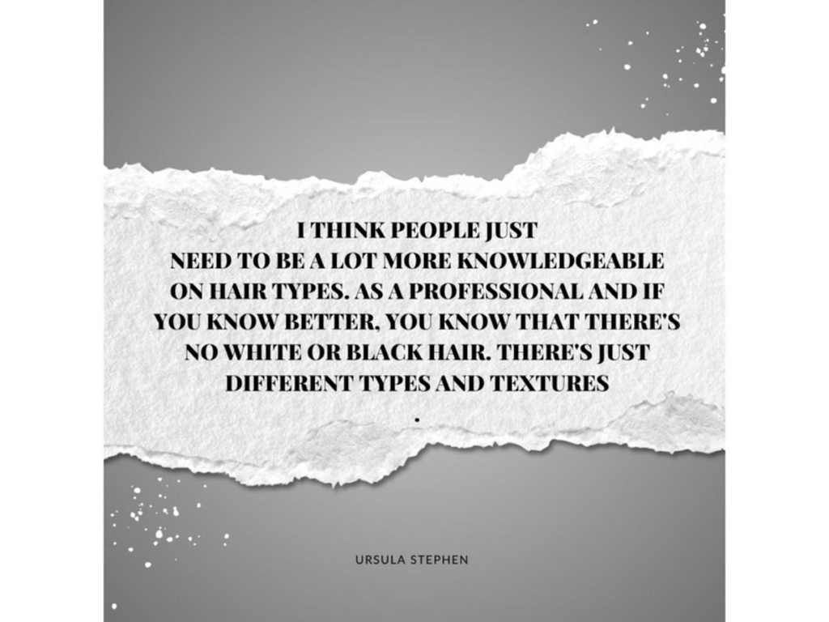

1. T. D. Allen, L. T. Eby, M. L. Poteet, E. Lentz, and L. Lima, “Career Benefits Associated with Mentoring for Protégés: A Meta‑Analysis,” *Journal of Applied Psychology*, 2004, https://psycnet.apa.org/fulltext/2004-15660-007.html. ↩︎
2. Yusef Williams, “Profile: Yusef Williams on Creative Mentorship,” *Vogue*, 2020, https://www.vogue.com/article/yusef-williams-interview; Naeemah Lafond, “Inside Amika: Naeemah Lafond’s Vision,” *Modern Salon*, 2019, https://www.modernsalon.com/article/naeemah-lafond; Harper’s Bazaar, “Vernon François: Championing Textured Hair,” 2021, https://www.harpersbazaar.com/beauty/hair. ↩︎
3. Bernard R. Ragins and K. E. Kram, eds., *The Handbook of Mentoring at Work: Theory, Research, and Practice* (Thousand Oaks, CA: Sage Publications, 2007). ↩︎
4. Kathy E. Kram, *Mentoring at Work: Developmental Relationships in Organizational Life* (Glenview, IL: Scott, Foresman, 1985). ↩︎
5. Peter M. Senge, *The Fifth Discipline: The Art & Practice of The Learning Organization* (New York: Doubleday, 1990). ↩︎
6. Marco Reyes, “Editorial Profile: Marco Reyes on Mentorship in High‑Fashion Hair,” *WWD*, 2018, https://wwd.com/beauty-industry-news/hair/marco-reyes-profile. ↩︎
7. Vidal Sassoon and Michael O’Donnell, *Vidal: The Autobiography* (New York: Macmillan, 2010). ↩︎
8. European Hair Professionals, “The Hair Has No Gender Project: Fostering Inclusive Beauty,” 2020, https://www.europeanhairpro.com/HHNG. ↩︎

VI

Mastering

the

Business

of

Hairstyling

> "Whatever you do, work at it with all your heart, as working for the Lord, not for human masters."

— Colossians 3:23

## Introduction

**P**icture this powerful scene: You stand poised behind your styling chair, ready to transform a simple canvas of hair into a masterpiece. As you begin to weave your magic, a sudden thought invades—are your business skills as sharp as the tools in your hands? In the fast-paced world of hairstyling, where artistry and entrepreneurship dance an intricate duet, mastering the business side is as essential as perfecting your hands-on craft. The key to a flourishing, sustainable career lies in mastering both the creative and financial aspects, allowing your creativity to soar while securing the financial stability and growth you richly deserve.[^1]

The psychology of business mastery in hairstyling involves a unique mindset—a blend of creativity, strategy, passion, and purpose. This chapter explores how aligning a love for hairstyling with sound business strategies can transform your career into a thriving, purpose-driven enterprise. We’ll guide you through setting income goals that align with your values, diversifying revenue streams, crafting unforgettable client experiences, and utilizing technology—all crucial elements for moving from mere survival to true success in the industry.

Whether you’re new to freelancing or an experienced pro seeking growth, this chapter will help you rewire your mindset, enhance your skills, and unlock your potential as a hairstyling business owner. Let’s dive into the strategies that will empower you to master both the art and the business of hairstyling.

## 1. Financial Management for Hairstylists

Mastering financial management is essential for sustainable success in the hairstyling business. This section covers setting income goals that align with your personal values, implementing effective accounting and financial tracking, and diversifying your revenue streams for stability. Let’s dive into each of these strategies.

### 1.A. Setting Income Goals Aligned with Personal Values

Financial goals for a hairstylist should go beyond arbitrary numbers; they should be deeply rooted in your personal and professional values. Start by reflecting on what truly matters to you: Are you seeking financial freedom, the ability to give back to your community, or a work-life balance that enhances your lifestyle?[^2]

Values-driven income goals help anchor your career to a purpose. For example, if community impact is a priority, you might decide to allocate a portion of your profits to local causes or offer discounted services to underserved populations. If financial security is your focus, you may aim to build a savings cushion that provides stability, regardless of industry fluctuations.

*Actionable Steps:*

- **Identify Core Values:** Reflect on what you value most—whether that’s financial independence, community impact, or career longevity.
- **Translate Values into Income Goals:** For example, if financial security is a key value, set a specific target for savings, emergency funds, or income diversification over the next 1–5 years.
- **Create a Vision Board or Goal Manifesto:** Use images, quotes, and income targets to visually connect your goals with your values. Keep this vision board where you can see it daily for motivation.

> Aligning my financial goals with my personal values was a transformative turning point. Early in my career, I chased revenue without a clear connection to my deeper creative ambitions. When I began setting income targets that resonated with my core values—authenticity, creativity, and community—I reimagined my entire approach to business. This shift allowed me to price my services in a way that truly reflected who I am, attracting clients who valued that same authenticity. The result was a more fulfilling, purpose-driven practice that balanced financial success with personal satisfaction.

### 1.B. Implementing Accounting Systems and Financial Tracking

After defining income goals, create a system to track your earnings and expenses, helping you manage cash flow effectively. For independent stylists, accurate recordkeeping is vital for identifying profit trends, understanding expenses, and planning for taxes.[^3]

Choose a system that matches your business’s complexity and scale. Options range from simple spreadsheets for those starting out to robust accounting software like QuickBooks or Xero, which offer tools for invoicing, tracking expenses, and generating financial reports. By maintaining meticulous records, you gain a clear view of your business’s financial health and can make informed decisions.

*Actionable Steps:*

- **Select an Accounting Method:** Evaluate options such as manual spreadsheets or software programs (QuickBooks, Xero) based on your needs.
- **Commit to Weekly Financial Reviews:** Set aside time weekly to update records, monitor expenses, and review income.
- **Develop a 12-Month Cash Flow Projection:** Use your historical data to forecast income and expenses, adjusting as needed to align with your income goals.

### 1.C. Exploring Diverse Revenue Streams for Stability

To build resilience in your business, consider diversifying your revenue streams beyond standard client services. This can provide a buffer during slower periods, allowing for a more stable income. Some successful hairstylists expand by selling products, teaching workshops, creating digital content, or offering specialized services.[^4]

Evaluate market demand and your strengths to identify complementary revenue streams that fit your brand. For example, if you specialize in color treatments, offering color-care products or tutorials on maintaining color at home can create additional income and support your primary services.

**Digital Revenue Opportunities:** Today’s hairstylists can expand their reach beyond the physical salon through digital offerings. Consider creating online tutorials, membership sites with exclusive content, virtual color or style consultations, or digital courses teaching specialized techniques. These digital extensions of your expertise can serve clients regardless of geographic limitations and create passive income streams that work for you even when you’re not behind the chair.

*Actionable Steps:*

- **Identify Potential Revenue Streams:** Consider products or services that naturally align with your hairstyling practice, such as product sales, online tutorials, or styling workshops.
- **Conduct Market Research:** Assess demand, pricing, and competition for each potential revenue stream to prioritize the most viable options.
- **Plan a Test Launch:** Roll out one new revenue stream in a controlled test phase with clear success metrics. Adjust based on client feedback and financial performance.
- **Develop a Digital Extension Strategy:** Create a plan for offering virtual services or digital products that complement your in-person offerings.

## 2. Building and Maintaining Client Relationships

In hairstyling, your relationships with clients are at the heart of your business. Beyond delivering high-quality services, understanding your clients’ unique needs and preferences fosters loyalty, trust, and satisfaction, which can translate into referrals and long-term business growth. This section covers strategies to understand client archetypes, design personalized service experiences, and use CRM software for effective communication.

### 2.A. Understanding Client Archetypes and Motivations

Clients come to stylists with different motivations, needs, and personalities. Recognizing these patterns can help you better anticipate their expectations and create an experience tailored to their preferences. Common client archetypes may include “Trendsetters” eager to try new styles, “Minimalists” who seek simple and manageable cuts, or “Reassurers” looking for trusted advice to solve specific hair challenges. By segmenting your clients, you can address each group’s unique priorities and enhance their overall experience.[^5]

For example, a Trendsetter may respond well to a stylist who offers creative suggestions, while a Minimalist might appreciate guidance on low-maintenance hairstyles. Understanding these archetypes also helps in preparing targeted communication that resonates with their individual needs.

**Client Archetype Framework:**

| Archetype | Key Characteristics | Service Approach | Communication Style |
| --- | --- | --- | --- |
| Trendsetter | Fashion-forward, open to change, social media savvy | Offer newest techniques, suggest creative options | Visual, trend-focused, enthusiastic |
| Minimalist | Values simplicity, prioritizes low maintenance, practical | Focus on ease of styling, durability of results | Clear, concise, emphasize longevity and simplicity |
| Reassurer | Cautious about changes, seeks expert guidance, loyal | Thorough consultations, gradual changes | Detailed explanations, reassuring, educational |
| Transformer | Seeking significant change, often at life transitions | Comprehensive consultations, dramatic results | Empathetic, affirming, celebratory |
| Luxury Seeker | Values premium experience, less price-sensitive | Enhanced amenities, exclusive products | Sophisticated, focused on quality and exclusivity |

*Actionable Steps:*

- **Identify Key Client Archetypes:** Review your existing clients and group them into 3-5 archetypes based on their common preferences and motivations.
- **Develop Profiles for Each Archetype:** Include key details like demographics, style preferences, typical requests, and their approach to hair maintenance.
- **Adjust Service Offerings to Fit Each Archetype:** Tailor consultations, product recommendations, and styling suggestions to meet the specific desires and concerns of each client type.

### 2.B. Designing Personalized Service Experiences

Once you understand client archetypes, the next step is to enhance each touchpoint in the client journey to make every interaction memorable. Personalization can set you apart, as clients feel valued and appreciated when their stylist remembers their preferences and goes above and beyond in providing care.

Design your client journey to include thoughtful touches from appointment booking to aftercare advice. Simple actions, such as offering a custom aftercare plan or a follow-up message after a major style change, can significantly enhance client satisfaction and strengthen loyalty.

*Actionable Steps:*

- **Map Out the Client Journey:** List all stages of interaction from booking to follow-up, identifying areas to add personal touches.
- **Create a “Wow Factor” for Each Archetype:** Develop a special touch for each client type (e.g., product samples for Trendsetters, care tips for Reassurers).
- **Train Staff for Consistency:** Ensure your team understands and contributes to delivering a consistent and personalized experience for each client.

> I vividly remember a time when going the extra mile for a client made all the difference. One client came in during a particularly emotional period as she prepared for a major life event. Instead of offering a standard service, I took the time to understand her vision and the emotions behind it. I customized her experience down to the finest details and even followed up with a handwritten note after her event. This personalized approach not only made her feel uniquely cared for but also led to a ripple effect of referrals. It was a powerful reminder that investing in genuine, heartfelt service can dramatically improve both client relationships and business growth.

### 2.C. Utilizing CRM Software for Targeted Communication

As your client list grows, keeping track of personal details and preferences for each individual can become challenging. Customer Relationship Management (CRM) software can organize and streamline client data, helping you maintain personalized communication. A CRM allows you to track each client’s history, preferences, and hair needs, providing insights that enable targeted outreach for promotions, follow-ups, and reminders.[^6]

For instance, if a client regularly books color services, you can send automated reminders about touch-up appointments or promotions on color-safe products. CRM tools like Salesforce, HubSpot, or salon-specific software like Mindbody can centralize this data, making it easier to enhance each client’s experience.

*Actionable Steps:*

- **Select a CRM Platform:** Research options that best suit your business size and budget, considering features like appointment scheduling, client history tracking, and automated messaging.
- **Build Detailed Client Profiles:** Store key details in each client profile, such as color formulas, past treatments, preferred styles, and communication preferences.
- **Create a Communication Plan:** Use CRM features to automate relevant communication, like birthday messages, appointment reminders, or product recommendations based on past purchases.

## 3. Marketing Your Hairstyling Business

An effective marketing strategy is crucial to building a successful hairstyling business. By establishing a strong brand identity, creating valuable content, leveraging digital platforms, and collaborating with local businesses, you can attract new clients and retain loyal ones. This section covers actionable techniques to elevate your business’s visibility and strengthen your brand presence.

### 3.A. Developing a Strong Brand Identity

A distinctive brand identity helps you stand out in a crowded market. Your brand should reflect who you are as a stylist, the values you uphold, and the experience you aim to provide. Branding goes beyond visuals—though a logo and cohesive color scheme are important; it encompasses your personality, the quality of your work, and your unique service approach.[^7]

Consider what makes your business unique, whether it’s a commitment to eco-friendly products, expertise in textured hair, or a focus on precision cuts. Crafting a brand story that communicates these values will attract clients who resonate with your approach.

*Actionable Steps:*

- **Define Your Unique Value Proposition (UVP):** Identify what sets your services apart and appeals to your ideal client base. Describe the specific benefits clients gain from working with you.
- **Create a Brand Style Guide:** Develop a style guide that includes your logo, colors, fonts, and tone of voice, ensuring that your brand is visually and tonally consistent across all platforms.
- **Audit Your Online Presence:** Review your website, social media, and marketing materials to confirm they consistently reflect your brand’s personality, values, and UVP.

### 3.B. Creating Compelling Content and Portfolios

High-quality content is essential for engaging potential clients and building credibility as a hairstyling expert. A strong portfolio showcases your skills, versatility, and expertise in a way that attracts your target audience. Content like before-and-after photos, video tutorials, and behind-the-scenes shots can demonstrate your capabilities and provide insight into your styling process.

Aim to educate and inspire with your content, offering valuable tips on hair care, styling techniques, or trend insights. This approach not only highlights your skillset but positions you as a trusted resource for clients.

*Actionable Steps:*

- **Curate a Content Calendar:** Plan a schedule for sharing different types of content, such as transformations, client testimonials, and hair care tips, across your website, blog, and social media.
- **Invest in Quality Photography and Video:** Use professional equipment or hire a photographer to capture high-resolution images and videos of your work, ensuring your portfolio appears polished and professional.
- **Leverage Client Testimonials:** Share client testimonials and stories as part of your content to build trust and showcase your impact on clients’ confidence and satisfaction.

### 3.C. Leveraging Social Media and Digital Channels

Social media offers a powerful platform to reach new clients, stay connected with current ones, and build a community around your brand. Platforms like Instagram, Facebook, and Pinterest allow you to showcase your work, interact with clients, and attract followers interested in your services.[^8]

By sharing relevant, high-quality posts and engaging with followers, you can establish a compelling online presence. Paid ads on social media can also help you reach new audiences who align with your target demographic, directing traffic to your booking site or salon.

**Beginner-Friendly Social Media Approach:**

1. **Start With One Platform**: Focus on mastering a single platform (typically Instagram for hairstylists) before expanding.
2. **Create a Content Framework**: Establish a simple posting pattern (e.g., Monday: inspiration, Wednesday: technique tips, Friday: client transformations).
3. **Use Simple Tools**: Utilize user-friendly apps like Canva for graphics and Planoly for scheduling posts.
4. **Engage Authentically**: Respond to comments and messages promptly and personally.
5. **Track Basic Metrics**: Monitor which types of content receive the most engagement and adjust accordingly.

*Actionable Steps:*

- **Optimize Your Social Media Profiles:** Ensure each profile clearly states who you are, what you offer, and how clients can book with you. Use your brand colors, logo, and UVP consistently.
- **Engage with Your Audience:** Respond to comments, answer questions, and interact with followers’ content to foster a community and build relationships with potential clients.
- **Experiment with Paid Advertising:** Consider running ads targeting your ideal clients, focusing on key services, seasonal promotions, or branded events to attract bookings and awareness.

> My journey into social media was one marked by honest hesitation and gradual discovery. Initially, I doubted whether my creative process and authentic voice could shine amid the crowded digital landscape. I observed others who had successfully built vibrant communities online, yet I felt uncertain about finding my own path. During the pre-launch and post-launch of my eBook, I began experimenting—sharing behind-the-scenes glimpses, candid moments, and even my occasional missteps. While the process was challenging, each step taught me valuable lessons about genuine engagement. Today, I’m still in the process of discovering and refining my digital presence, but every interaction brings me closer to building a community that values authenticity over perfection.

### 3.D. Collaborating on Events and Experiences

Collaborations and events can expand your reach, introduce you to new audiences, and strengthen your professional network. Teaming up with complementary businesses—such as makeup artists, photographers, boutiques, or wellness centers—creates opportunities to showcase your skills in unique settings and attract clients who might otherwise not encounter your brand.

Collaborative events can include styling demos, pop-up salon services, or workshops on hair care and styling tips. Choose partnerships that reflect your brand’s values and aesthetic to ensure a natural alignment with your ideal clientele.

**Regional Marketing Adaptations:** Your marketing strategy should be tailored to your specific geographic context. In metropolitan areas, highlight your distinctive specialization to stand out in a competitive market. In suburban or rural communities, emphasize community connections and accessibility. Consider how pricing and service offerings might need to be adjusted based on your local market’s economic conditions and client expectations.

*Actionable Steps:*

- **Identify Potential Collaboration Partners:** Look for businesses or professionals who share similar values and serve an overlapping client base, such as fashion boutiques, wellness brands, or local influencers.
- **Plan an Event or Experience:** Brainstorm collaborative ideas like a styling demo, wellness day, or client appreciation event that will engage both your audiences.
- **Document and Share the Experience:** Capture photos and videos from the event to share on social media, tagging your partner to maximize reach and engagement.
- **Conduct Local Market Analysis:** Research pricing standards, competitive offerings, and client demographics in your area to optimize your marketing approach for your specific region.

### 3.E. Case Study: Marquetta Breslin - Building a Thriving Lace Wig Business

Marquetta Breslin’s journey offers an inspiring and instructive example of how hairstylists can turn a niche service into a full-fledged business and personal brand. Known for her expertise in lace wig creation, Breslin not only established a reputation for her craftsmanship but also empowered others by sharing her specialized knowledge through education.[^9]

#### From Stylist to Specialist

Initially a traditional hairstylist, Breslin observed a growing need among clients experiencing hair loss due to medical conditions and other factors. Her solution was to create high-quality, natural-looking lace wigs that offered clients more than just hair—they offered emotional and physical transformation. Recognizing the personal and transformative nature of this service, Breslin dedicated herself to mastering the nuances of lace wig creation, investing significant time in learning intricate techniques such as ventilating, coloring, and custom styling.

Breslin’s approach was deeply client-focused. She understood that her work involved more than just technical expertise; it required empathy and insight into the lives of her clients, many of whom were navigating the challenges of hair loss. This client-centered dedication contributed to her strong reputation and differentiated her in a competitive market, establishing Breslin as a compassionate, trusted specialist.

#### Scaling Through Education

Recognizing an opportunity to share her expertise with other stylists, Breslin launched an online training program in 2006 focused on the art and business of lace wig-making. Her program, Lace Wig University, includes video tutorials, templates, support, and business guidance. This innovative educational platform allowed her to reach a global audience, offering stylists the tools and knowledge needed to expand their skills and build businesses in the lace wig market. By packaging her expertise into online courses, Breslin successfully diversified her revenue streams, generating passive income while expanding her influence and impact.

Breslin’s training program has empowered stylists worldwide, providing them with a pathway to build careers based on high-quality, compassionate wig services. Today, her educational reach has grown significantly, and her program remains a key resource for stylists interested in this specialized field. The success of Lace Wig University demonstrates the scalability of educational products, enabling hairstylists to extend their impact far beyond the salon.

#### Lessons Learned

Breslin’s career journey highlights valuable lessons for freelance hairstylists aiming to establish sustainable, impactful businesses:

1. **Specialization**: Breslin’s success underscores the power of finding a unique niche. Specializing in lace wigs allowed her to address a specific market need, distinguishing her from other stylists and positioning her as an industry expert.
2. **Education**: Continuous learning and skill development elevated Breslin’s service quality, building her credibility and enabling her to create educational resources that benefited others.
3. **Scalability**: By transforming her knowledge into online courses, Breslin multiplied her influence and income potential beyond what was possible through one-on-one client services alone.
4. **Branding**: Establishing a strong online presence helped amplify Breslin’s brand, attracting a loyal client base and opening doors for partnerships and collaborative opportunities.

Whether you’re considering launching a product line, creating an educational platform, or developing a niche service, Breslin’s journey offers a blueprint. Her example shows that with focus, dedication, and strategic thinking, it’s possible to turn a hairstyling skill into a transformative, sustainable business.

### 3.F. Building Economic Resilience in Your Business

The hairstyling industry is subject to economic fluctuations that can impact client spending patterns. Creating a recession-resistant business model helps ensure stability during economic downturns while positioning you for growth during prosperous periods.[^10]

*Strategies for Economic Resilience:*

- **Tiered Service Offerings**: Create service packages at different price points to accommodate clients across various budget ranges.
- **Emergency Fund**: Maintain a business savings account with 3-6 months of operating expenses.
- **Flexible Scheduling**: Consider offering extended hours or alternative scheduling options to accommodate clients with changing work situations.
- **Value-Added Services**: Develop services that help clients extend the life of their styles, providing better value during tight economic times.
- **Subscription Models**: Create membership or package deals that provide steady income through recurring revenue.

By implementing these practices, you can create a business that withstands economic challenges while continuing to provide exceptional value to clients regardless of market conditions.

## 4. Conclusion: Crowning Your Passion with Prosperity

As we conclude this chapter, it’s clear that mastering the business of hairstyling involves far more than simply honing technical skills. True success in this field requires a dynamic blend of artistry, entrepreneurial acumen, and unwavering dedication to personal and professional growth. In each of the strategies covered—from aligning income goals with values, maintaining strong client relationships, and building a memorable brand to diversifying income streams and managing finances—you now have a roadmap to propel your business forward.

The essence of hairstyling as a business lies in adaptability, resilience, and a commitment to continuous learning. Embracing these qualities, and staying attuned to the ever-evolving needs of clients and industry trends, will guide you toward not just a sustainable career but one that flourishes. By remaining true to your unique vision, nurturing your relationships, and welcoming innovation, you position yourself as a transformative force within the industry.

Whether you are in the early stages of your career or looking to redefine your path, remember that the business of hairstyling is a journey—a creative and entrepreneurial endeavor where every challenge is an opportunity. The tools, insights, and strategies provided in this chapter are designed to support your ambition to not only succeed but to elevate your craft, your business, and, ultimately, your life. So, embrace your journey with confidence and joy, knowing that your passion for hairstyling is both your gift to the world and the foundation of a prosperous future.

> Embracing these interconnected business practices has truly redefined my career. By aligning my income goals with my personal values, delivering tailored, heartfelt client experiences, and stepping into the digital world with vulnerability and curiosity, I’ve achieved not only enhanced profitability but also deep personal fulfillment. Every strategy reinforces the other, creating a holistic business model that feels both sustainable and true to my creative spirit. Ultimately, this journey has taught me that success is best measured by the balance of financial growth and the joy of living authentically every day.

### Key Takeaways

1. Mastering hairstyling as a business requires a blend of technical skill, financial knowledge, and an entrepreneurial spirit.
2. Setting income goals aligned with your values, managing finances, and diversifying income are keys to a sustainable career.
3. Designing personalized client experiences and nurturing strong relationships help you stand out in a competitive market.
4. Developing a compelling brand identity, creating valuable content, and leveraging digital marketing channels are powerful ways to attract and engage clients.
5. Business mastery is a marathon, requiring ongoing learning, adaptability, and resilience to thrive in a dynamic industry.

## Quiz

### Question 1

What is the first step in mastering your finances as a hairstylist?

- A) Implementing a bookkeeping system
- B) Setting income goals aligned with your personal values
- C) Diversifying your revenue streams
- D) Hiring a financial advisor

### Question 2

Which of the following is NOT an effective way to diversify your income as a freelance hairstylist?

- A) Offering additional services like makeup or nails
- B) Selling hair care products online or in your salon
- C) Raising your prices for all services across the board
- D) Teaching workshops or creating educational content

### Question 3

What is the purpose of segmenting your clients into archetypes?

- A) To create a more efficient booking system
- B) To tailor your communication, services, and marketing to their specific needs
- C) To determine which clients to prioritize over others
- D) To track client loyalty and reward frequent visitors

### Question 4

Which of the following is an example of leveraging social media for your hairstyling business?

- A) Posting before-and-after photos and videos of your work
- B) Promoting other local businesses on your profile
- C) Sharing personal updates unrelated to your business
- D) Keeping your account private and only accessible to clients

## Worksheet

### Business Model Canvas

This worksheet is designed to help you outline your hairstyling business model, focusing on each component of the Business Model Canvas.

1. **Key Partners: List your business’s key partners and suppliers, including the nature of these partnerships and how they support your business.**
2. **Key Activities: Describe the core activities that your business undertakes to deliver value to your customers, such as client consultations, hair treatments, marketing, or inventory management.**
3. **Key Resources: Identify the essential resources needed to carry out your business’s activities, including physical assets, intellectual property, human resources, and financial assets.**
4. **Value Propositions: Outline the unique value your business offers clients. What differentiates your services in the hairstyling industry, and how do they meet your customers’ needs?**
5. **Customer Relationships: Describe how your business builds and maintains client relationships, aiming to foster loyalty and satisfaction.**
6. **Customer Segments: Define the specific segments of clients your business targets, including their needs, preferences, and characteristics.**

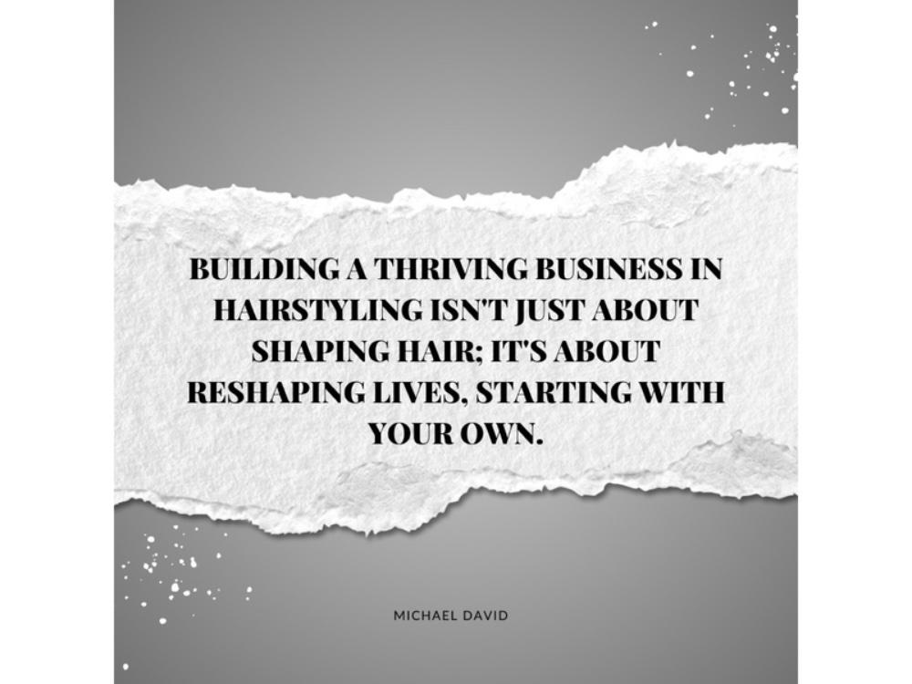

1. Albert Bandura, *Self‑Efficacy: The Exercise of Control* (New York: Worth Publishers, 1997), accessed March 8, 2025, https://www.uky.edu/~eushe2/Bandura/Bandura1997EP.pdf. ↩︎
2. Carol S. Dweck, *Mindset: The New Psychology of Success* (New York: Random House, 2006). ↩︎
3. Intuit, “QuickBooks Online,” 2023, accessed March 8, 2025, https://quickbooks.intuit.com. ↩︎
4. Modern Salon, “Revenue Diversification Strategies for Freelancers,” 2021, accessed March 8, 2025, https://www.modernsalon.com/revenue-diversification. ↩︎
5. Kevin Lane Keller, *Strategic Brand Management* (Upper Saddle River, NJ: Prentice Hall, 2003). ↩︎
6. Salesforce, “Salesforce CRM for Small Businesses,” 2023, accessed March 8, 2025, https://www.salesforce.com. ↩︎
7. Kevin Lane Keller, *Strategic Brand Management* (Upper Saddle River, NJ: Prentice Hall, 2003). ↩︎
8. Hootsuite, “Social Media Marketing Best Practices,” 2023, accessed March 8, 2025, https://hootsuite.com/resources/social-media-marketing. ↩︎
9. Marquetta Breslin, “Building a Thriving Lace Wig Business,” *WWD*, 2018, accessed March 8, 2025, https://wwd.com/beauty-industry-news/hair/marquetta-breslin-profile. ↩︎
10. Salon Business Journal, “Economic Resilience Strategies for Hairstylists,” 2022, accessed March 8, 2025, https://www.salonbusinessjournal.com. ↩︎

VII

Embracing

Wellness

and

Self-Care

> "Do you not know that your bodies are temples of the Holy Spirit, who is in you, whom you have received from God? You are not your own; you were bought at a price."

— 1 Corinthians 6:19-20 (NIV)

## Introduction

**S**tep into your salon, not just as a stylist ready to craft beautiful looks, but as someone grounded in health, resilience, and purpose. Picture the energy and passion you’d bring to every interaction, knowing you’ve invested in your own well-being. Self-care in hairstyling isn’t just about managing stress; it’s about redefining what it means to be successful, creative, and fulfilled.

This chapter is an invitation to embrace a new narrative, one where self-care is not a luxury, but a foundation of your artistry and career longevity. We’ll explore how caring for your body, mind, and emotions enhances your professional life, protecting you from burnout and enriching your ability to connect with clients. When you embody wellness, you don’t just show up for your clients—you inspire and uplift them.

Together, we’ll walk through strategies to support your physical health, manage the emotional demands of the job, and build a supportive network that reinforces your commitment to self-care. Prepare to experience the transformative power of nurturing your body, mind, and spirit. Let’s dive in and create a self-care routine that powers your journey to a fulfilling and sustainable career in hairstyling.

## Personal Anecdote: The Day I Almost Quit

Three years into my freelance journey, I found myself in the emergency room with severe lower back pain that had been building for months. As I lay on that cold hospital bed, unable to stand without shooting pain, I realized I’d been so focused on building my business that I’d completely neglected my own well-being. The doctor’s words hit me like a wake-up call: “If you don’t change how you’re treating your body, you’ll be forced to change careers.”

That night, staring at the ceiling of my apartment, I made a choice. I could either continue down the path of physical deterioration and burnout, or I could learn to care for myself with the same dedication I showed my clients. The next morning, I bought my first ergonomic stool, scheduled a massage, and blocked out lunch breaks in my calendar for the first time ever. Six months later, not only was my back pain gone, but I was more creative, energetic, and present with my clients than I’d ever been. That emergency room visit taught me that self-care isn’t selfish—it’s essential for serving others at the highest level.

**Key Insight:** Taking care of yourself isn’t taking away from your clients; it’s preparing yourself to give them your very best.

## I. Fortifying the Temple: Physical Self-Care Strategies

Hairstyling is a physically demanding profession. Long hours on your feet, repetitive motions, and awkward postures can lead to muscle strain, joint pain, and even chronic injuries. Protecting your physical health is not just beneficial—it’s essential for a sustainable career. This section delves into strategies to optimize your workspace ergonomics, incorporate therapeutic stretching and strengthening routines, and prioritize nutrition for sustained energy and recovery.

### 1.A. Ergonomic Workspace Optimization

Hairstyling requires precision and prolonged periods of concentration, often resulting in repetitive motions that can strain the body. Optimizing your workspace ergonomics is a critical step in preventing physical ailments and ensuring long-term health.[^1]

Consider an ergonomic assessment of your workspace, identifying specific areas for improvement. Adjustable equipment, such as cutting stools, anti-fatigue mats, ergonomic shears, and appropriate lighting, can make a significant difference in your comfort and productivity. For further guidance, consulting an occupational therapist may provide a tailored plan for improved physical comfort and longevity.

## Case Study: Jen Atkin’s Wellness-First Approach

**Real-Life Example: Jen Atkin, Celebrity Hairstylist**

**Challenge:** As one of the most sought-after celebrity hairstylists working with A-list clients like Kim Kardashian and Chrissy Teigen, Jen Atkin faced the intense demands of a high-pressure career that included long working hours, constant travel, and the physical demands of hairstyling.

**Solution:** Atkin developed a comprehensive wellness routine that includes starting every morning with tea, writing in a Five-Minute Journal, and practicing meditation using Hoffman Process guided meditations. She emphasizes structure and routine as key elements of her self-care practice, viewing wellness as essential to maintaining her creativity and professional performance.

**Outcome:** Through her commitment to wellness practices, Atkin has successfully built a global hair care brand (Ouai) while maintaining her position as a top celebrity stylist. Her approach to wellness has become part of her professional brand, and she frequently shares self-care tips with her audience and industry peers.

**Lessons Learned:** Implementing consistent daily wellness practices, even simple ones like journaling and meditation, can help manage the physical and mental demands of a high-pressure hairstyling career while maintaining creativity and professional excellence.[^8]

### 1.B. Building Physical Strength and Flexibility

Regular exercise, particularly activities that strengthen your core and improve flexibility, can significantly reduce the risk of work-related injuries. Research shows that nearly half of hairdressers experience knee and foot pain (49.5%), followed by lower back pain (39.8%) and upper back pain (38.8%).[^9] Incorporating yoga, pilates, or targeted stretching routines can help counteract the physical demands of long working hours.

### 1.C. Nutrition for Sustained Energy

Working in a salon environment can be dehydrating, especially when using heat tools or working in hot conditions. Proper nutrition and hydration are essential for maintaining energy levels throughout long shifts. Focus on balanced meals that provide sustained energy and avoid relying on caffeine or sugar for quick fixes that lead to energy crashes.

## II. Nurturing Mental and Emotional Well-being

### 2.A. Mindfulness and Stress Management

The emotional demands of working closely with clients, managing schedules, and maintaining creative output can lead to mental fatigue. Developing mindfulness practices helps manage stress and maintain emotional equilibrium throughout demanding workdays.

### 2.B. Setting Professional Boundaries

Learning to set healthy boundaries with clients and in your schedule is crucial for preventing burnout. This includes managing client expectations, scheduling appropriate breaks, and maintaining work-life balance.

### 2.C. Engaging in Creative Renewal Activities

Creativity thrives when it’s nourished. To maintain inspiration and avoid burnout, make time for creative renewal. This could mean attending a hair show, taking a workshop, or collaborating with other artists. Creativity also flourishes through interests outside of hairstyling, such as hobbies, travel, or spending time in nature.

Creative renewal involves seeking activities that allow you to step outside your comfort zone, bringing fresh perspectives back to your work.

## Actionable Steps

1. **Find an Online Forum:** Join hairstyling forums or communities on platforms like Facebook, Instagram, or LinkedIn, actively engaging with members to share knowledge and support. Participating in discussions, asking questions, and offering advice can enrich your professional network.
2. **Create a Mastermind Group:** Start a small, confidential group where stylists set goals, share expertise, and hold one another accountable for their professional growth. Regular mastermind sessions can provide structured support and collective problem-solving.
3. **Attend Webinars and Virtual Events:** Participate in online industry events to gain fresh ideas, stay connected to global trends, and expand your professional network. Webinars and virtual conferences often feature experts sharing the latest techniques and business strategies.
4. **Engage in Online Challenges:** Join hairstyling challenges or competitions hosted online to test your skills, gain exposure, and connect with other stylists. These challenges can push you to innovate and showcase your talent to a broader audience.
5. **Leverage Social Media Groups:** Participate in closed social media groups dedicated to hairstyling professionals. These groups can be a valuable source of inspiration, advice, and support from peers and industry veterans.

### 3.C. Engaging in Collaborative Projects and Events

Collaborating with other creatives—makeup artists, photographers, designers—offers an exciting way to expand your skills, portfolio, and client base. These partnerships not only broaden your horizons but can also help you feel re-energized and creatively fulfilled. Engaging in collaborative events fosters community bonds, connects you with potential clients, and positions you as an active contributor to the beauty industry.

*Actionable Steps:*

- **Propose a Collaboration:** Reach out to other local artists to work on projects together, such as photoshoots, fashion shows, or styled events. Collaborations can lead to mutual referrals and showcase your combined talents to a wider audience.
- **Volunteer at Community Events:** Offer your hairstyling skills at charity events or fundraisers, connecting with your community in meaningful ways and expanding your client base. Volunteering not only gives back but also enhances your reputation as a community-oriented professional.
- **Organize a Creative Workshop:** Plan and lead workshops to share your expertise, connect with fellow creatives, and build your reputation as a thought leader in hairstyling. Workshops can also generate additional income and attract potential clients interested in learning from you.
- **Participate in Pop-Up Salons:** Engage in pop-up salon events to offer your services in unique settings, such as fashion shows, bridal expos, or local festivals. These events can increase your visibility and attract clients who might not visit your regular salon.
- **Collaborate on Educational Content:** Team up with other professionals to create educational content like video tutorials, blog posts, or online courses. Sharing knowledge not only establishes your authority but also provides value to your audience and potential clients.

## III. Nurturing the Creative Community: Social Support Systems

Building and nurturing a support system is an essential part of any hairstylist’s journey. Your peers, mentors, and local creative community serve as anchors, providing encouragement, inspiration, and practical support. Engaging with a network can help you stay motivated, learn from others, and strengthen your professional impact.

### 3.A. Building Local Peer Networks and Alliances

Creating strong, local connections brings a sense of community and shared purpose. Engaging with hairstyling associations or groups can lead to valuable friendships, opportunities, and resources, supporting you in a fast-paced and competitive industry. Whether you’re participating in regular meetings, creating a mastermind group, or partnering with other salons, these connections foster mutual support and resilience.

### 3.B. Participating in Online Forums and Masterminds

In today’s digital age, connecting with hairstylists and industry leaders around the world can be transformative. Online forums and mastermind groups offer the flexibility to learn from others, stay current on trends, and gain insights from diverse perspectives. Masterminds, in particular, are excellent for peer-to-peer learning and structured growth, helping stylists advance professionally and personally.

## V. Minimum Viable Self-Care: Where to Begin

If you’re feeling overwhelmed by the comprehensive self-care practices described in this chapter, start with this simplified approach. The “Minimum Viable Self-Care” framework focuses on high-impact, low-effort interventions that can fit into even the busiest schedule.[^6]

### Wellness Implementation Ladder

This progressive approach helps you build a sustainable self-care routine over time rather than trying to adopt everything at once:

| Stage | Focus Area | Simple Action | Time Investment |
| --- | --- | --- | --- |
| Foundation | Hydration & Movement | Water bottle at station, basic stretches | 5 min/day |
| Building | + Nutrition & Boundaries | Meal prep once weekly, set work hours | +15 min/day |
| Strengthening | + Mental Well-being | Daily mindfulness practice, peer connection | +15 min/day |
| Thriving | + Creative Renewal | Monthly creative project, quarterly education | +30 min/day |

Remember: Even implementing just the Foundation stage will yield significant benefits for your well-being and career longevity. The goal is progress, not perfection.

### Healthcare Resources for Freelancers

As a freelance hairstylist, securing affordable healthcare can be challenging. Consider these resources:[^7]

- **Professional Associations:** Organizations like the Professional Beauty Association (PBA) and Associated Hair Professionals (AHP) offer access to group health insurance plans with more competitive rates than individual policies.
- **Healthcare Sharing Ministries:** For those comfortable with faith-based options, programs like Medi-Share or Christian Healthcare Ministries can provide cost-sharing alternatives to traditional insurance.
- **Freelancers Union:** Joining the Freelancers Union gives access to their healthcare marketplace with plans specifically designed for independent workers.
- **Local Chamber of Commerce:** Many chambers offer group health insurance options to member businesses, including sole proprietors.
- **Health Insurance Marketplace:** The government-run marketplace at Healthcare.gov may provide subsidized plans based on your income level.

Investing in preventive care through regular checkups and addressing physical issues early can save substantial costs and prevent career-threatening injuries in the long run.

## Key Takeaways

1. Self-care is essential for preventing burnout, sustaining creativity, and building a fulfilling career in hairstyling.
2. Physical health matters: Optimize your workspace ergonomically, build strength, and prioritize balanced nutrition to maintain stamina.
3. Mindfulness and boundaries protect mental and emotional well-being, helping stylists manage stress, stay grounded, and maintain healthy client relationships.
4. Community support: Building connections within the hairstyling industry fosters growth, inspiration, and professional opportunities.
5. Self-care is a commitment to yourself and your career, creating a positive impact on clients, colleagues, and the industry at large.

## Quiz

### Question 1

Why is ergonomic workspace optimization important for hairstylists?

- A) It helps attract more clients
- B) It's a legal requirement for all salons
- C) It can help prevent pain, injury, and strain over time
- D) It's a passing trend in the industry

### Question 2

Which of the following is NOT a recommended strategy for physical self-care?

- A) Regular stretching and strengthening exercises
- B) Using ergonomic tools and equipment
- C) Skipping meals to save time between clients
- D) Staying hydrated with water throughout the day

### Question 3

What is one benefit of practicing mindfulness and meditation for hairstylists?

- A) It guarantees a fully booked schedule
- B) It eliminates the need for continuing education
- C) It can help reduce stress and increase focus and clarity
- D) It automatically solves all problems with difficult clients

### Question 4

Why is it important for hairstylists to engage in creative renewal activities?

- A) It's a requirement for maintaining a cosmetology license
- B) It can help prevent burnout and keep stylists inspired and motivated
- C) It's the only way to learn new skills and techniques
- D) It's a waste of time that takes away from client work

## Worksheet

### Self-Care and Wellness Plan

1. **Self-Care Activity Planning: Describe a self-care activity you plan to integrate into your routine. What is it, and when will you do it?**
2. **What barriers have prevented you from prioritizing this activity in the past? Reflect on any negative beliefs or logistical challenges.**
3. **What outcomes do you hope to achieve by incorporating this activity into your life? Consider both immediate and long-term benefits for your physical and mental well-being.**
4. **After trying your chosen self-care activity for one week, reflect on your experience. Did you encounter any challenges in integrating it into your routine?**
5. **How did engaging in this self-care activity affect your well-being? Note any changes in mood, stress levels, or overall satisfaction.**
6. **Did this experiment challenge any negative beliefs about self-care? Describe any shifts in your perspective.**
7. **Will you make this self-care activity a regular part of your routine? Why or why not?**
8. **Based on the “Minimum Viable Self-Care” framework, which one daily practice could you realistically commit to starting tomorrow?**
9. **What stage of the Wellness Implementation Ladder are you currently at, and what specific action will help you move to the next stage?**

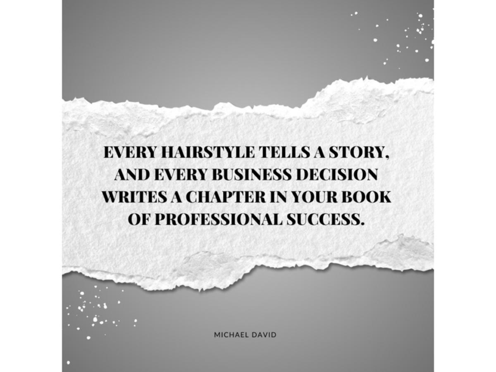

1. U.S. Occupational Safety and Health Administration, “Ergonomics in the Workplace,” 2020, accessed March 8, 2025, https://www.osha.gov/ergonomics. ↩︎
2. Jen Atkin, “Glamour Columnist and Hair Stylist to the Stars Jen Atkin Shares Her Self-Care Tips,” Hoffman Institute, accessed July 21, 2025, https://www.hoffmaninstitute.org/glamour-columnist-and-hair-stylist-to-the-stars-jen-atkin-shares-her-self-care-tips-to-get-us-through-lockdown/. ↩︎
3. National Center for Biotechnology Information, “Work-related musculoskeletal disorders and associated risk factors among urban metropolitan hairdressers in India,” PMC, accessed July 21, 2025, https://pmc.ncbi.nlm.nih.gov/articles/PMC7883474/. ↩︎
4. Healthline, “Quick Self‑Care Tips,” 2021, accessed March 8, 2025, https://www.healthline.com. ↩︎
5. Freelancers Union, “Health Insurance Options for Freelancers,” 2023, accessed March 8, 2025, https://www.freelancersunion.org. ↩︎

VIII

Advancing

Skills

Through

Continuous

Education

> "Let the wise listen and add to their learning, and let the discerning get guidance."

— Proverbs 1:5

## Introduction

**E**nvision a breathtaking, transformative hairstyle that captures attention and admiration for its beauty and the skill behind it. Now, envision yourself as the artist behind it, armed with knowledge, creativity, and mastery—the essence of a hairstylist who thrives on continuous education. In an industry marked by relentless evolution, where trends change at a moment’s notice, the power to learn, adapt, and innovate is indispensable.[^1]

But continuous education goes beyond mastering the latest techniques; it’s about reawakening the passion, curiosity, and creative potential that first drew you into hairstyling. It’s about transcending comfort zones, challenging assumptions, and nurturing your artistic spirit. This chapter invites you on a journey into the world of lifelong learning for hairstylists. We’ll explore accessible avenues for skill advancement, from online courses and in-person workshops to mentorships and international artistic immersions. We’ll uncover insights from industry leaders who have redefined their careers through learning and growth and guide you to build an education plan tailored to your ambitions and style.

Whether you’re a seasoned pro ready to rekindle your passion or a newcomer eager to make a mark, this chapter is your gateway to a life of professional reinvention and discovery. Together, let’s unlock the endless possibilities that continuous education brings.

## Personal Anecdote: The Workshop That Changed Everything

I recall a turning point early in my career when I attended an intensive workshop led by a master stylist whose innovative techniques reshaped my perspective on hairstyling. In that immersive environment, I not only learned advanced skills but also discovered the importance of infusing creativity into every cut and color. This experience ignited a passion for continual learning and experimentation, shifting my approach from simply following trends to developing my own signature style.

The workshop lasted three days, but its impact lasted years. I watched this master stylist work with such precision and creativity that I realized I had been operating at only a fraction of my potential. When I returned to my salon, I felt like I was seeing hair through completely new eyes. Every client became an opportunity to apply what I’d learned, and my confidence soared. That workshop didn’t just teach me new techniques—it taught me that education is the bridge between where you are and where you want to be in this industry.

**Key Insight:** Continuous education isn’t just about learning new techniques; it’s about expanding your creative vision and discovering possibilities you never knew existed.

## I. The Online Classroom - Your Portal to Global Expertise

### 1.A. Virtual Academies & Masterclasses: Learn from Legends

Imagine having the world’s leading hairstylists as your personal instructors, guiding you through cutting-edge techniques and inspiring creativity right from your home or salon. Online academies and masterclasses provide stylists with unprecedented access to the insights and skills of top industry professionals. Platforms like Aveda’s education programs, MHD (MyHairDressers), and Pulp Riot deliver comprehensive courses covering everything from foundational cuts and color techniques to advanced styling and sustainability practices. Aveda, known for its emphasis on both technical skills and sustainable beauty, offers extensive programs that provide stylists with advanced techniques while also encouraging environmentally conscious practices, allowing learners to understand the bigger picture of beauty and sustainability.[^2]

Masterclasses offer shorter, in-depth sessions on specific topics, often delivered by influential stylists known for expertise in techniques like balayage, texturing, and advanced color. Hairstylist Tutorials, Behind the Chair, and SalonCentric are just a few platforms that offer masterclasses tailored to the latest trends, sometimes with live Q&A sessions that enable direct engagement with educators. The ability to pause, rewind, and replay these tutorials allows stylists to absorb and perfect techniques at their own pace, an invaluable feature that traditional education can’t always offer.

*Actionable Steps:*

- **Research and Compare:** Identify and evaluate virtual academies that align with your goals. Look at reviews and previews, and select a platform that matches your technical level and learning style.
- **Set a Dedicated Schedule:** Treat online courses like in-person classes, allocating specific times each week for uninterrupted learning.
- **Engage Actively:** Participate in discussions, assignments, and Q&A sessions to deepen your understanding and network with peers.
- **Apply and Share:** Practice new techniques with clients or on mannequins, and document your progress to share with your community, fostering feedback and growth.

## Case Study: Sam Villa’s Educational Revolution

**Real-Life Example: Sam Villa, Master Hairdresser and Educator**

**Challenge:** As a successful hairstylist, Sam Villa wanted to share his knowledge and help elevate the entire industry through education, while also continuing his own learning journey throughout his career.

**Solution:** Villa built a comprehensive educational empire that includes online platforms, live workshops, weekly training sessions, and mentorship programs. He offers “SkillsUP” monthly classes for students, weekly “Mannequin Monday” and “Transformation Tuesday” sessions, and has partnered with schools to provide students with professional tools and education. His philosophy centers on the belief that “Education has broadened my outlook on trends, it promotes the ‘how’ in technique and enhances communication skills and business skills.”

**Outcome:** Villa received the 2018 NAHA Lifetime Achievement Award and the International Hairdressing Awards Influencer of the Year, confirming his impact as an educator. His educational programs have reached thousands of stylists worldwide, with many crediting his teachings for transforming their careers and elevating their technical skills.

**Lessons Learned:** Continuous education benefits both the learner and the teacher. Villa’s success demonstrates that investing in education creates a ripple effect that elevates the entire industry, and that true mastery comes from never ceasing to learn—“as hairdressers, we must never cease to learn…as people we must never cease to learn!”[^18]

### 1.B. Interactive Cohort Programs & Mentorships: Accelerate Growth with Guidance

Beyond self-paced courses, interactive cohort programs and mentorships provide a unique blend of structure, community, and direct guidance from industry leaders. Programs like Mane Addicts’ Fuel Education Series and StreetWise’s Evolve Series create small, intensive groups where participants collaborate on assignments, engage in live sessions, and receive one-on-one coaching. The Doux, founded by Maya Smith, offers a special focus on textured hair education, providing invaluable insight into the art of managing and styling naturally curly hair. Maya Smith’s emphasis on embracing the natural beauty of textured hair resonates deeply with stylists eager to enhance their knowledge of curl-specific techniques and create styles that celebrate hair’s unique characteristics.

The cohort format encourages stylists to form a supportive community, offering motivation and accountability as they progress through the curriculum together.

Mentorship programs take this learning one step further by pairing stylists with experienced mentors who offer personalized advice, feedback, and support. Platforms such as Hairbrained Mentorship Program and Beauty Connect Mentorship match stylists with mentors aligned to their career goals, providing guidance through regular check-ins. These mentorships offer invaluable insights into industry practices and open doors to new opportunities through networking and referrals.[^3]

*Actionable Steps:*

- **Identify Programs and Apply:** Research cohort and mentorship programs that match your goals, experience level, and preferred learning environment. Be ready to commit both time and energy.
- **Engage Fully:** Show up for every session prepared and motivated, and be an active participant in group discussions and projects.
- **Build Relationships:** Network within your cohort and connect with your mentor outside formal sessions, fostering a professional support system.
- **Set Personal Goals:** Define specific learning objectives for the program and work with your mentor to achieve these milestones, tracking your growth over time.

## II. Global Artistry Adventures: Immersing in International Inspiration

### 2.A. Ancestral Techniques & Philosophies: Honoring Hairstyling Heritage

Traveling to learn ancestral techniques allows stylists to tap into centuries-old traditions that enrich their work and bring a deeper level of authenticity and respect for diverse hairstyles. Regions like West Africa are renowned for intricate braiding techniques, while Japan is celebrated for its precision cuts. These cultural immersions provide a hands-on experience in styles and philosophies that might otherwise remain unexplored, grounding your work in a broader context.[^4]

For instance, learning traditional African braiding methods provides insight into how these techniques hold cultural and personal significance, symbolizing beauty, status, and community connection. Meanwhile, Japanese hairstyling emphasizes precision, mindfulness, and respect for form—a mindset that can transform a stylist’s approach to even the simplest haircut. Stylists who engage with these traditions not only expand their technical skills but also gain a sense of global artistry that resonates with a diverse clientele.

*Actionable Steps:*

- **Research Programs:** Look for study-abroad or immersion programs in regions renowned for unique hairstyling traditions. Programs that balance technical skill development with cultural learning offer the most comprehensive experience.
- **Prepare with Cultural Awareness:** Before departure, learn about the cultural customs and significance of hairstyling in the region. Understanding the historical and social background of these techniques enhances respect and learning.
- **Document Your Journey:** Use photos, videos, and journaling to capture techniques and philosophies. Share insights with your community to increase awareness and appreciation for global hairstyling.

### 2.B. Indigenous Master Instructors: Learning from Living Legends

Training directly with indigenous master instructors offers stylists the rare opportunity to learn from individuals who are deeply connected to traditional hairstyling wisdom. Programs like South Africa’s Natural Hair Academy and Vietnam’s Long Hair Village allow participants to delve into indigenous practices that honor hair as both an aesthetic and spiritual medium.[^5]

Collaborating with these master instructors provides more than just technical skills; it imparts a holistic understanding of hairstyling, where each strand of hair carries meaning. For example, traditional hair styling programs in New Zealand incorporate Māori cultural elements that integrate symbolism, tradition, and respect for heritage. Working with these mentors fosters humility and reverence, teaching stylists to approach hair not merely as a canvas but as an extension of personal and cultural identity.

*Actionable Steps:*

- **Reach Out to Indigenous Academies:** Express interest in learning from indigenous instructors respectfully. Be transparent about your intentions and prepared to observe any cultural protocols.
- **Research Traditions:** Before training, learn about the symbolic and spiritual importance of hairstyles in indigenous communities.
- **Respect Cultural Context:** Approach learning with an open mind and a commitment to respecting the cultural significance of each practice. Offer your own skills and knowledge to give back and honor the instructors’ teachings.

## III. The Mastery Mentorship Catalyst: Apprenticing with Iconic Innovators

### 3.A. Luminary Alignment: Finding Your Guiding Stars

In every industry, those who achieve iconic status have often done so through a blend of innate skill, relentless work, and invaluable mentorship. For hairstylists, aligning with a mentor who embodies the artistry, skill, and professional acumen you aspire to can accelerate your development and open doors that would otherwise remain closed. But mentorship isn’t merely about technique; it’s about absorbing philosophies, habits, and mindsets that fuel creative and professional success.[^6]

The key to finding the right mentor begins with identifying your core goals and values. Are you drawn to avant-garde styling, editorial work, or innovative color techniques? Do you admire a stylist who has built a global brand or one known for pioneering sustainable practices in beauty? By exploring your personal career aspirations, you can pinpoint mentors who resonate with your goals, artistic style, and brand vision.

**Key Areas for Mentorship Evaluation:**

- **Artistic Style and Technique:** Does this mentor specialize in areas you’re passionate about—be it cutting-edge color techniques, precision cutting, or curly hair artistry?
- **Clientele and Market Niche:** Examine the mentor’s target market. Are they entrenched in high-fashion editorial work, high-profile celebrity styling, or high-end salon ownership?
- **Brand and Business Approach:** From salon ownership to influencer marketing, today’s mentors wear multiple hats. Find someone whose business model aligns with where you see yourself.
- **Teaching and Communication Style:** Look for a mentor whose approach to feedback and teaching aligns with how you best learn and grow.

*Actionable Steps:*

- **Create a Mentor Wish List:** Identify 5-10 industry leaders you admire, taking notes on their career trajectory, skills, and the traits you hope to learn.
- **Immerse Yourself in Their Work:** Study their portfolio, philosophy, and public presentations. Understanding their work will prepare you to connect on a meaningful level.
- **Reach Out with Intentionality:** Craft a genuine message explaining what you admire about their work and how their guidance aligns with your aspirations.
- **Build a Relationship Gradually:** Begin by attending their workshops, joining their online courses, or following them on social media. Engaging with their content consistently can lead to organic mentorship.

> Finding an industry mentor was a journey marked by both hesitation and breakthrough moments. Initially, I was intimidated by the idea of reaching out to someone I deeply admired, worried that my inexperience might be a barrier. However, once I took the plunge, I discovered that genuine connection transcends titles and credentials. Although scheduling conflicts and differing perspectives presented early challenges, my mentor’s willingness to share insights and offer honest feedback transformed those obstacles into invaluable learning opportunities. My advice for anyone seeking mentorship is to approach the process with authenticity and persistence—don’t be afraid to show vulnerability, as it is often the key to unlocking profound professional growth.